# Portafolio Curso de Métodos Numéricos

MONSERRATH ANTONIO CORDERO

04 December, 2025

# Sistemas de punto flotante

```r
## Función para convertir parte entera a binario

decimal_a_binario <- function(num) {
  parte_entera <- floor(num)
  parte_decimal <- num - parte_entera

  bin_entero <- ""
  if (parte_entera == 0) {
    bin_entero <- "0"
  } else {
    while (parte_entera > 0) {
      bin_entero <- paste0(parte_entera %% 2, bin_entero)
      parte_entera <- parte_entera %/% 2
    }
  }

## Parte decimal

  bin_decimal <- ""
  count <- 0
  while (parte_decimal > 0 && count < 8) {
    parte_decimal <- parte_decimal * 2
    bit <- floor(parte_decimal)
    bin_decimal <- paste0(bin_decimal, bit)
    parte_decimal <- parte_decimal - bit
    count <- count + 1
  }

  if (nchar(bin_decimal) > 0) {
    return(paste0(bin_entero, ".", bin_decimal))
  } else {
    return(bin_entero)
  }
}

## EjERCICIOS:
decimal_a_binario(246)
```

```
## [1] "11110110"
```

```r
decimal_a_binario(345.68)
```

```
## [1] "101011001.10101110"
```

```r
decimal_a_binario(4586632.2846)
```

```
## [1] "10001011111110010001000.01001000"
```

```r
decimal_a_binario(984365.27463)
```

```
## [1] "11110000010100101101.01000110"
```

```r
decimal_a_binario(79905523)
```

```
## [1] "100110000110100001011110011"
```

```r
## Función para redondear a 4 cifras significativas
round_4sig <- function(x) signif(x, digits = 4)

## Eliminación Gaussiana Simple con redondeo
gauss_simple <- function(M) {
  n <- nrow(M)
  for (k in 1:(n-1)) {
    for (i in (k+1):n) {
      factor <- round_4sig(M[i,k] / M[k,k])
      M[i, k:ncol(M)] <- round_4sig(M[i, k:ncol(M)] - factor * M[k, k:ncol(M)])
    }
    cat(sprintf("\nMatriz después de eliminar la columna %d:\n", k))
    print(M)
  }
  return(M)
}

## Sustitución regresiva con redondeo
back_substitution <- function(M) {
  n <- nrow(M)
  x <- numeric(n)
  for (i in n:1) {
    suma <- if (i == n) 0 else sum(M[i, (i+1):n] * x[(i+1):n])
    x[i] <- round_4sig((M[i, ncol(M)] - suma) / M[i,i])
  }
  return(x)
}
```

## — Ejercicio 1 —

```r
A1 <- matrix(c(
  1, -2, 0.5, -5,
  -2, 5, -1.5, 0,
  -0.2, 1.75, -1, 10
), nrow=3, byrow=TRUE)

cat("Ejercicio 1 - Matriz aumentada original:\n")
```

```
## Ejercicio 1 - Matriz aumentada original:
```

```r
print(A1)
```

```
##      [,1]  [,2] [,3] [,4]
## [1,]  1.0 -2.00  0.5   -5
## [2,] -2.0  5.00 -1.5    0
## [3,] -0.2  1.75 -1.0   10
```

```r
M1 <- gauss_simple(A1)
```

```
##
## Matriz después de eliminar la columna 1:
##      [,1]  [,2] [,3] [,4]
## [1,]    1 -2.00  0.5   -5
## [2,]    0  1.00 -0.5  -10
## [3,]    0  1.35 -0.9    9
##
## Matriz después de eliminar la columna 2:
##      [,1] [,2]   [,3]  [,4]
## [1,]    1   -2  0.500  -5.0
## [2,]    0    1 -0.500 -10.0
## [3,]    0    0 -0.225  22.5
```

```r
x1 <- back_substitution(M1)

cat("\nSolución Ejercicio 1:\n")
```

```
##
## Solución Ejercicio 1:
```

```r
for (i in 1:length(x1)) cat(sprintf("x%d = %.4g\n", i, x1[i]))
```

```
## x1 = -75
## x2 = -60
## x3 = -100
```

## — Ejercicio 2 —

```r
A2 <- matrix(c(
  0.003000, 59.14, 59.17,
  5.291, -6.130, 46.78
), nrow=2, byrow=TRUE)

cat("\nEjercicio 2 - Matriz aumentada original:\n")
```

```
##
## Ejercicio 2 - Matriz aumentada original:
```

```r
print(A2)
```

```
##       [,1]  [,2]  [,3]
## [1,] 0.003 59.14 59.17
## [2,] 5.291 -6.13 46.78
```

```r
M2 <- gauss_simple(A2)
```

```
##
## Matriz después de eliminar la columna 1:
##        [,1]       [,2]       [,3]
## [1,]  0.003      59.14      59.17
## [2,] -0.001 -104300.00 -104300.00
```

```r
x2 <- back_substitution(M2)

cat("\nSolución Ejercicio 2:\n")
```

```
##
## Solución Ejercicio 2:
```

```r
for (i in 1:length(x2)) cat(sprintf("x%d = %.4g\n", i, x2[i]))
```

```
## x1 = 10
## x2 = 1
```

## — Ejercicio 3 —

```r
A3 <- matrix(c(
  3, -0.1, -0.2, 7.85,
  0.1, 7, -0.3, -19.3,
  0.3, -0.2, 10, 71.4
), nrow=3, byrow=TRUE)

cat("\nEjercicio 3 - Matriz aumentada original:\n")
```

```
##
## Ejercicio 3 - Matriz aumentada original:
```

```r
print(A3)
```

```
##      [,1] [,2] [,3]   [,4]
## [1,]  3.0 -0.1 -0.2   7.85
## [2,]  0.1  7.0 -0.3 -19.30
## [3,]  0.3 -0.2 10.0  71.40
```

```r
M3 <- gauss_simple(A3)
```

```
##
## Matriz después de eliminar la columna 1:
##            [,1]   [,2]    [,3]   [,4]
## [1,]  3.000e+00 -0.100 -0.2000   7.85
## [2,]  1.000e-05  7.003 -0.2933 -19.56
## [3,] -5.551e-17 -0.190 10.0200  70.62
##
## Matriz después de eliminar la columna 2:
##            [,1]       [,2]    [,3]   [,4]
## [1,]  3.000e+00 -1.000e-01 -0.2000   7.85
## [2,]  1.000e-05  7.003e+00 -0.2933 -19.56
## [3,] -5.551e-17 -8.610e-06 10.0100  70.09
```

```r
x3 <- back_substitution(M3)

cat("\nSolución Ejercicio 3:\n")
```

```
##
## Solución Ejercicio 3:
```

```r
for (i in 1:length(x3)) cat(sprintf("x%d = %.4g\n", i, x3[i]))
```

```
## x1 = 3
## x2 = -2.5
## x3 = 7.002
```

## — Ejercicio 4 —

```r
A4 <- matrix(c(
  4, 2, 0, 2,
  2, 3, 1, -1,
  0, 1, 2.5, 3
), nrow = 3, byrow = TRUE)

cat("\nEjercicio 4 - Matriz aumentada original:\n")
```

```
##
## Ejercicio 4 - Matriz aumentada original:
```

```r
print(A4)
```

```
##      [,1] [,2] [,3] [,4]
## [1,]    4    2  0.0    2
## [2,]    2    3  1.0   -1
## [3,]    0    1  2.5    3
```

```r
M4 <- gauss_simple(A4)
```

```
##
## Matriz después de eliminar la columna 1:
##      [,1] [,2] [,3] [,4]
## [1,]    4    2  0.0    2
## [2,]    0    2  1.0   -2
## [3,]    0    1  2.5    3
##
## Matriz después de eliminar la columna 2:
##      [,1] [,2] [,3] [,4]
## [1,]    4    2    0    2
## [2,]    0    2    1   -2
## [3,]    0    0    2    4
```

```r
x4 <- back_substitution(M4)

cat("\nSolución Ejercicio 4:\n")
```

```
##
## Solución Ejercicio 4:
```

```r
for (i in 1:length(x4)) cat(sprintf("x%d = %.4g\n", i, x4[i]))
```

```
## x1 = 1.5
## x2 = -2
## x3 = 2
```

## — Ejercicio 5 —

```r
A5 <- matrix(c(
  3, -0.1, -0.2, 7.85,
  0.1, 7, -0.3, -19.3,
  0.3, -0.2, 10, 71.4
), nrow = 3, byrow = TRUE)

cat("Ejercicio 5 - Matriz aumentada original:\n")
```

```
## Ejercicio 5 - Matriz aumentada original:
```

```r
print(A5)
```

```
##      [,1] [,2] [,3]   [,4]
## [1,]  3.0 -0.1 -0.2   7.85
## [2,]  0.1  7.0 -0.3 -19.30
## [3,]  0.3 -0.2 10.0  71.40
```

```r
M5 <- gauss_simple(A5)
```

```
##
## Matriz después de eliminar la columna 1:
##            [,1]   [,2]    [,3]   [,4]
## [1,]  3.000e+00 -0.100 -0.2000   7.85
## [2,]  1.000e-05  7.003 -0.2933 -19.56
## [3,] -5.551e-17 -0.190 10.0200  70.62
##
## Matriz después de eliminar la columna 2:
##            [,1]       [,2]    [,3]   [,4]
## [1,]  3.000e+00 -1.000e-01 -0.2000   7.85
## [2,]  1.000e-05  7.003e+00 -0.2933 -19.56
## [3,] -5.551e-17 -8.610e-06 10.0100  70.09
```

```r
x5 <- back_substitution(M5)

cat("\nSolución Ejercicio 5:\n")
```

```
##
## Solución Ejercicio 5:
```

```r
for (i in 1:length(x5)) cat(sprintf("x%d = %.4g\n", i, x5[i]))
```

```
## x1 = 3
## x2 = -2.5
## x3 = 7.002
```

## — Ejercicio 9 —

```r
A9 <- matrix(c(
  1.133, 5.281, -2.454, 6.414,
  24.14, -1.21, 5.281, 113.8,
  -10.123, 6.387, -1, 1
), nrow = 3, byrow = TRUE)

cat("Ejercicio 9 - Matriz aumentada original:\n")
```

```
## Ejercicio 9 - Matriz aumentada original:
```

```r
print(A9)
```

```
##         [,1]   [,2]   [,3]    [,4]
## [1,]   1.133  5.281 -2.454   6.414
## [2,]  24.140 -1.210  5.281 113.800
## [3,] -10.123  6.387 -1.000   1.000
```

```r
M9 <- gauss_simple(A9)
```

```
##
## Matriz después de eliminar la columna 1:
##           [,1]     [,2]    [,3]    [,4]
## [1,]  1.133000    5.281  -2.454   6.414
## [2,] -0.004230 -113.700  57.580 -22.880
## [3,]  0.000355   53.570 -22.930  58.310
##
## Matriz después de eliminar la columna 2:
##           [,1]       [,2]   [,3]    [,4]
## [1,]  1.133000    5.28100 -2.454   6.414
## [2,] -0.004230 -113.70000 57.580 -22.880
## [3,]  0.000355   -0.00544  4.202  47.530
```

```r
x9 <- back_substitution(M9)

cat("\nSolución Ejercicio 9:\n")
```

```
##
## Solución Ejercicio 9:
```

```r
for (i in 1:length(x9)) cat(sprintf("x%d = %.4g\n", i, x9[i]))
```

```
## x1 = 2.522
## x2 = 5.929
## x3 = 11.31
```

## — Ejercicio 10 —

```r
A10 <- matrix(c(
  2, 3, 2, 4,
  4, 10, -4, 0,
  -3, -2, -5, -2,
  -2, 4, 4, -7
), nrow = 4, byrow = TRUE)

b10 <- c(9, -15, 6, 2)

Ab10 <- cbind(A10, b10)

cat("Ejercicio 10 - Matriz aumentada original:\n")
```

```
## Ejercicio 10 - Matriz aumentada original:
```

```r
print(A1)
```

```
##      [,1]  [,2] [,3] [,4]
## [1,]  1.0 -2.00  0.5   -5
## [2,] -2.0  5.00 -1.5    0
## [3,] -0.2  1.75 -1.0   10
```

```r
M10 <- gauss_simple(A10)
```

```
##
## Matriz después de eliminar la columna 1:
##      [,1] [,2] [,3] [,4]
## [1,]    2  3.0    2    4
## [2,]    0  4.0   -8   -8
## [3,]    0  2.5   -2    4
## [4,]    0  7.0    6   -3
##
## Matriz después de eliminar la columna 2:
##      [,1] [,2] [,3] [,4]
## [1,]    2    3    2    4
## [2,]    0    4   -8   -8
## [3,]    0    0    3    9
## [4,]    0    0   20   11
##
## Matriz después de eliminar la columna 3:
##      [,1] [,2]   [,3] [,4]
## [1,]    2    3  2.000    4
## [2,]    0    4 -8.000   -8
## [3,]    0    0  3.000    9
## [4,]    0    0 -0.001  -49
```

```r
x10 <- back_substitution(M10)

cat("\nSolución Ejercicio 10:\n")
```

```
##
## Solución Ejercicio 10:
```

```r
for (i in 1:length(x10)) cat(sprintf("x%d = %.4g\n", i, x10[i]))
```

```
## x1 = 0
## x2 = 0
## x3 = 0
## x4 = 1
```

## Observaciones

1. Falta historia de los métodos numéricos
2. Falta resumen/revisión de tipos de errores

# Solución de sistemas de ecuaciones lineales

### Gauss con pivoteo parcial

```r
gauss_pivoteo_pasos <- function(A) {
  A <- as.matrix(A)
  n <- nrow(A)
  cat("Matriz aumentada inicial:\n")
  print(round(A, 6)); cat("\n")


  for (i in 1:(n - 1)) {
    ## Pivoteo parcial
    max_row <- which.max(abs(A[i:n, i])) + i - 1
    if (max_row != i) {
      cat(paste("Intercambio fila", i, "<->", max_row, "\n"))
      A[c(i, max_row), ] <- A[c(max_row, i), ]
      print(round(A, 6)); cat("\n")
    }

    for (j in (i + 1):n) {
      factor <- A[j, i] / A[i, i]
      cat(paste("Eliminando A[", j, ",", i, "] con factor =", round(factor, 6), "\n"))
      A[j, i:ncol(A)] <- A[j, i:ncol(A)] - factor * A[i, i:ncol(A)]
      print(round(A, 6)); cat("\n")
    }
  }

  ## Sustitución regresiva
  x <- rep(0, n)
  for (i in n:1) {
    if (i < n) {
      suma <- sum(A[i, (i+1):n] * x[(i+1):n])
    } else {
      suma <- 0
    }
    x[i] <- (A[i, n+1] - suma) / A[i, i]
  }

  cat("Solución final:\n")
  print(round(x, 6))
  return(x)
}
```

## — EJERCICIO 1 —

```r
A1 <- matrix(c(
  0.4, -1.5,  0.75, -20,
 -0.5, -15,   10,   -10,
 -10,  -9,    2.5,   30
), nrow = 3, byrow = TRUE)

gauss_pivoteo_pasos(A1)
```

```
## Matriz aumentada inicial:
##       [,1]  [,2]  [,3] [,4]
## [1,]   0.4  -1.5  0.75  -20
## [2,]  -0.5 -15.0 10.00  -10
## [3,] -10.0  -9.0  2.50   30
##
## Intercambio fila 1 <-> 3
##       [,1]  [,2]  [,3] [,4]
## [1,] -10.0  -9.0  2.50   30
## [2,]  -0.5 -15.0 10.00  -10
## [3,]   0.4  -1.5  0.75  -20
##
## Eliminando A[ 2 , 1 ] con factor = 0.05
##       [,1]   [,2]  [,3]  [,4]
## [1,] -10.0  -9.00 2.500  30.0
## [2,]   0.0 -14.55 9.875 -11.5
## [3,]   0.4  -1.50 0.750 -20.0
##
## Eliminando A[ 3 , 1 ] con factor = -0.04
##      [,1]   [,2]  [,3]  [,4]
## [1,]  -10  -9.00 2.500  30.0
## [2,]    0 -14.55 9.875 -11.5
## [3,]    0  -1.86 0.850 -18.8
##
## Eliminando A[ 3 , 2 ] con factor = 0.127835
##      [,1]   [,2]      [,3]     [,4]
## [1,]  -10  -9.00  2.500000  30.0000
## [2,]    0 -14.55  9.875000 -11.5000
## [3,]    0   0.00 -0.412371 -17.3299
##
## Solución final:
## [1] -18.8750  29.3125  42.0250
```

```
## [1] -18.8750  29.3125  42.0250
```

## — EJERCICIO 3 —

```r
A3 <- matrix(c(
  0.003, 59.14,   59.17,
  5.291, -6.13,   46.78
), nrow = 2, byrow = TRUE)

gauss_pivoteo_pasos(A3)
```

```
## Matriz aumentada inicial:
##       [,1]  [,2]  [,3]
## [1,] 0.003 59.14 59.17
## [2,] 5.291 -6.13 46.78
##
## Intercambio fila 1 <-> 2
##       [,1]  [,2]  [,3]
## [1,] 5.291 -6.13 46.78
## [2,] 0.003 59.14 59.17
##
## Eliminando A[ 2 , 1 ] con factor = 0.000567
##       [,1]     [,2]     [,3]
## [1,] 5.291 -6.13000 46.78000
## [2,] 0.000 59.14348 59.14348
##
## Solución final:
## [1] 10  1
```

```
## [1] 10  1
```

## — Ejercicio 5 —

```r
A5 <- matrix(c(
  0.00031, 1.000000, 3.000000,
  1.00045534, 1.00034333, 7.000
), nrow = 2, byrow = TRUE)

gauss_pivoteo_pasos(A5)
```

```
## Matriz aumentada inicial:
##          [,1]     [,2] [,3]
## [1,] 0.000310 1.000000    3
## [2,] 1.000455 1.000343    7
##
## Intercambio fila 1 <-> 2
##          [,1]     [,2] [,3]
## [1,] 1.000455 1.000343    7
## [2,] 0.000310 1.000000    3
##
## Eliminando A[ 2 , 1 ] con factor = 0.00031
##          [,1]     [,2]     [,3]
## [1,] 1.000455 1.000343 7.000000
## [2,] 0.000000 0.999690 2.997831
##
## Solución final:
## [1] 3.998389 2.998760
```

```
## [1] 3.998389 2.998760
```

## — Ejercicio 7 —

```r
A7 <- matrix(c(
  1/4, 1/5, 1/6,
  1/3, 1/4, 1/5,
  1/2, 1,   2
), nrow = 3, byrow = TRUE)

b7 <- c(9, 8, 8)

## Matriz aumentada
Ab7 <- cbind(A7, b7)

gauss_pivoteo_pasos(Ab7)
```

```
## Matriz aumentada inicial:
##                             b7
## [1,] 0.250000 0.20 0.166667  9
## [2,] 0.333333 0.25 0.200000  8
## [3,] 0.500000 1.00 2.000000  8
##
## Intercambio fila 1 <-> 3
##                             b7
## [1,] 0.500000 1.00 2.000000  8
## [2,] 0.333333 0.25 0.200000  8
## [3,] 0.250000 0.20 0.166667  9
##
## Eliminando A[ 2 , 1 ] con factor = 0.666667
##                                     b7
## [1,] 0.50  1.000000  2.000000 8.000000
## [2,] 0.00 -0.416667 -1.133333 2.666667
## [3,] 0.25  0.200000  0.166667 9.000000
##
## Eliminando A[ 3 , 1 ] con factor = 0.5
##                                    b7
## [1,] 0.5  1.000000  2.000000 8.000000
## [2,] 0.0 -0.416667 -1.133333 2.666667
## [3,] 0.0 -0.300000 -0.833333 5.000000
##
## Eliminando A[ 3 , 2 ] con factor = 0.72
##                                    b7
## [1,] 0.5  1.000000  2.000000 8.000000
## [2,] 0.0 -0.416667 -1.133333 2.666667
## [3,] 0.0  0.000000 -0.017333 3.080000
##
## Solución final:
## [1] -227.0769  476.9231 -177.6923
```

```
## [1] -227.0769  476.9231 -177.6923
```

## — Ejercicio 8 —

```r
A8 <- matrix(c(
  1,   1/2, 1/3, 1/4, 1/6,
  1/2, 1/3, 1/4, 1/5, 1/7,
  1/3, 1/4, 1/5, 1/6, 1/8,
  1/4, 1/5, 1/6, 1/7, 1/9
), nrow = 4, byrow = TRUE)

gauss_pivoteo_pasos(A8)
```

```
## Matriz aumentada inicial:
##          [,1]     [,2]     [,3]     [,4]     [,5]
## [1,] 1.000000 0.500000 0.333333 0.250000 0.166667
## [2,] 0.500000 0.333333 0.250000 0.200000 0.142857
## [3,] 0.333333 0.250000 0.200000 0.166667 0.125000
## [4,] 0.250000 0.200000 0.166667 0.142857 0.111111
##
## Eliminando A[ 2 , 1 ] con factor = 0.5
##          [,1]     [,2]     [,3]     [,4]     [,5]
## [1,] 1.000000 0.500000 0.333333 0.250000 0.166667
## [2,] 0.000000 0.083333 0.083333 0.075000 0.059524
## [3,] 0.333333 0.250000 0.200000 0.166667 0.125000
## [4,] 0.250000 0.200000 0.166667 0.142857 0.111111
##
## Eliminando A[ 3 , 1 ] con factor = 0.333333
##      [,1]     [,2]     [,3]     [,4]     [,5]
## [1,] 1.00 0.500000 0.333333 0.250000 0.166667
## [2,] 0.00 0.083333 0.083333 0.075000 0.059524
## [3,] 0.00 0.083333 0.088889 0.083333 0.069444
## [4,] 0.25 0.200000 0.166667 0.142857 0.111111
##
## Eliminando A[ 4 , 1 ] con factor = 0.25
##      [,1]     [,2]     [,3]     [,4]     [,5]
## [1,]    1 0.500000 0.333333 0.250000 0.166667
## [2,]    0 0.083333 0.083333 0.075000 0.059524
## [3,]    0 0.083333 0.088889 0.083333 0.069444
## [4,]    0 0.075000 0.083333 0.080357 0.069444
##
## Intercambio fila 2 <-> 3
##      [,1]     [,2]     [,3]     [,4]     [,5]
## [1,]    1 0.500000 0.333333 0.250000 0.166667
## [2,]    0 0.083333 0.088889 0.083333 0.069444
## [3,]    0 0.083333 0.083333 0.075000 0.059524
## [4,]    0 0.075000 0.083333 0.080357 0.069444
##
## Eliminando A[ 3 , 2 ] con factor = 1
##      [,1]     [,2]      [,3]      [,4]      [,5]
## [1,]    1 0.500000  0.333333  0.250000  0.166667
## [2,]    0 0.083333  0.088889  0.083333  0.069444
## [3,]    0 0.000000 -0.005556 -0.008333 -0.009921
## [4,]    0 0.075000  0.083333  0.080357  0.069444
##
## Eliminando A[ 4 , 2 ] con factor = 0.9
##      [,1]     [,2]      [,3]      [,4]      [,5]
## [1,]    1 0.500000  0.333333  0.250000  0.166667
## [2,]    0 0.083333  0.088889  0.083333  0.069444
## [3,]    0 0.000000 -0.005556 -0.008333 -0.009921
## [4,]    0 0.000000  0.003333  0.005357  0.006944
##
## Eliminando A[ 4 , 3 ] con factor = -0.6
##      [,1]     [,2]      [,3]      [,4]      [,5]
## [1,]    1 0.500000  0.333333  0.250000  0.166667
## [2,]    0 0.083333  0.088889  0.083333  0.069444
## [3,]    0 0.000000 -0.005556 -0.008333 -0.009921
## [4,]    0 0.000000  0.000000  0.000357  0.000992
##
## Solución final:
## [1] -0.031746  0.595238 -2.380952  2.777778
```

```
## [1] -0.03174603  0.59523810 -2.38095238  2.77777778
```

## — Ejercicio 9 —

```r
A9 <- matrix(c(
  2, 1, -1, 1, -3, 7,
  1, 0,  2, -1, 1, 2,
  0, -2, -1, 1, -1, -5,
  3, 1, -4, 0, 5, 6,
  1, -1, -1, -1, 1, 3
), nrow = 5, byrow = TRUE)

gauss_pivoteo_pasos(A9)
```

```
## Matriz aumentada inicial:
##      [,1] [,2] [,3] [,4] [,5] [,6]
## [1,]    2    1   -1    1   -3    7
## [2,]    1    0    2   -1    1    2
## [3,]    0   -2   -1    1   -1   -5
## [4,]    3    1   -4    0    5    6
## [5,]    1   -1   -1   -1    1    3
##
## Intercambio fila 1 <-> 4
##      [,1] [,2] [,3] [,4] [,5] [,6]
## [1,]    3    1   -4    0    5    6
## [2,]    1    0    2   -1    1    2
## [3,]    0   -2   -1    1   -1   -5
## [4,]    2    1   -1    1   -3    7
## [5,]    1   -1   -1   -1    1    3
##
## Eliminando A[ 2 , 1 ] con factor = 0.333333
##      [,1]      [,2]      [,3] [,4]      [,5] [,6]
## [1,]    3  1.000000 -4.000000    0  5.000000    6
## [2,]    0 -0.333333  3.333333   -1 -0.666667    0
## [3,]    0 -2.000000 -1.000000    1 -1.000000   -5
## [4,]    2  1.000000 -1.000000    1 -3.000000    7
## [5,]    1 -1.000000 -1.000000   -1  1.000000    3
##
## Eliminando A[ 3 , 1 ] con factor = 0
##      [,1]      [,2]      [,3] [,4]      [,5] [,6]
## [1,]    3  1.000000 -4.000000    0  5.000000    6
## [2,]    0 -0.333333  3.333333   -1 -0.666667    0
## [3,]    0 -2.000000 -1.000000    1 -1.000000   -5
## [4,]    2  1.000000 -1.000000    1 -3.000000    7
## [5,]    1 -1.000000 -1.000000   -1  1.000000    3
##
## Eliminando A[ 4 , 1 ] con factor = 0.666667
##      [,1]      [,2]      [,3] [,4]      [,5] [,6]
## [1,]    3  1.000000 -4.000000    0  5.000000    6
## [2,]    0 -0.333333  3.333333   -1 -0.666667    0
## [3,]    0 -2.000000 -1.000000    1 -1.000000   -5
## [4,]    0  0.333333  1.666667    1 -6.333333    3
## [5,]    1 -1.000000 -1.000000   -1  1.000000    3
##
```

[output cut: 51 more lines]

```
## [2,]    0   -2 -1.0  1.000000 -1.000000 -5.000000
## [3,]    0    0  3.5 -1.166667 -0.500000  0.833333
## [4,]    0    0  0.0  1.666667 -6.285714  1.809524
## [5,]    0    0  0.0 -1.333333  0.142857  4.095238
##
## Eliminando A[ 5 , 4 ] con factor = -0.8
##      [,1] [,2] [,3]      [,4]      [,5]      [,6]
## [1,]    3    1 -4.0  0.000000  5.000000  6.000000
## [2,]    0   -2 -1.0  1.000000 -1.000000 -5.000000
## [3,]    0    0  3.5 -1.166667 -0.500000  0.833333
## [4,]    0    0  0.0  1.666667 -6.285714  1.809524
## [5,]    0    0  0.0  0.000000 -4.885714  5.542857
##
## Solución final:
## [1]  1.918129  1.964912 -0.988304 -3.192982 -1.134503
```

```
## [1]  1.9181287  1.9649123 -0.9883041 -3.1929825 -1.1345029
```

## — Ejercicio 10 —

```r
A10 <- matrix(c(
  3.333, 15920, -10.333, 15913,
  2.222, 16.71, 9.612,   28.544,
  1.5611, 5.1791, 1.6852, 8.4254
), nrow = 3, byrow = TRUE)

gauss_pivoteo_pasos(A10)
```

```
## Matriz aumentada inicial:
##        [,1]       [,2]     [,3]       [,4]
## [1,] 3.3330 15920.0000 -10.3330 15913.0000
## [2,] 2.2220    16.7100   9.6120    28.5440
## [3,] 1.5611     5.1791   1.6852     8.4254
##
## Eliminando A[ 2 , 1 ] con factor = 0.666667
##        [,1]        [,2]      [,3]        [,4]
## [1,] 3.3330  15920.0000 -10.33300  15913.0000
## [2,] 0.0000 -10596.6233  16.50067 -10580.1227
## [3,] 1.5611      5.1791   1.68520      8.4254
##
## Eliminando A[ 3 , 1 ] con factor = 0.468377
##       [,1]      [,2]       [,3]       [,4]
## [1,] 3.333  15920.00 -10.333000  15913.000
## [2,] 0.000 -10596.62  16.500667 -10580.123
## [3,] 0.000  -7451.38   6.524938  -7444.855
##
## Eliminando A[ 3 , 2 ] con factor = 0.703184
##       [,1]      [,2]       [,3]          [,4]
## [1,] 3.333  15920.00 -10.333000  15913.000000
## [2,] 0.000 -10596.62  16.500667 -10580.122667
## [3,] 0.000      0.00  -5.078073     -5.078073
##
## Solución final:
## [1] 1 1 1
```

```
## [1] 1 1 1
```

## Gauss-Jordan

```r
gauss_jordan_step <- function(A, b) {
  n <- nrow(A)
  Ab <- cbind(A, b)

  cat("Matriz aumentada inicial:\n")
  print(round(Ab, 4))

  for (i in 1:n) {
    ## Si pivote es 0, buscar fila para intercambiar
    if (Ab[i, i] == 0) {
      for (k in (i+1):n) {
        if (Ab[k, i] != 0) {
          temp <- Ab[i, ]
          Ab[i, ] <- Ab[k, ]
          Ab[k, ] <- temp
          cat("\nIntercambio de filas", i, "y", k, "por pivote 0:\n")
          print(round(Ab, 4))
          break
        }
      }
    }

    if (Ab[i, i] == 0) {
      cat("\nNo se encontró un pivote distinto de cero. El sistema puede no tener solución única.\n")
      return(rep(NA, n))
    }

    ## Normalizar la fila
    pivote <- Ab[i, i]
    Ab[i, ] <- Ab[i, ] / pivote
    cat("\nDespués de dividir fila", i, "por pivote", round(pivote, 4), ":\n")
    print(round(Ab, 4))

    ## Hacer ceros en la columna
    for (j in 1:n) {
      if (j != i) {
        factor <- Ab[j, i]
        Ab[j, ] <- Ab[j, ] - factor * Ab[i, ]
      }
    }
    cat("\nDespués de hacer ceros en columna", i, ":\n")
    print(round(Ab, 4))
  }

  cat("\nSolución encontrada:\n")
  solution <- Ab[, n + 1]
  names(solution) <- paste0("x", 1:n)
  print(round(solution, 4))
  return(solution)
}
```

## — EJERCICIO 1 —

```r
A1 <- matrix(c(1, 2, 3,
               -0.4, 2, -1,
               0.5, -3, 1), nrow=3, byrow=TRUE)
b1 <- c(1, 10, 15)
sol1 <- gauss_jordan_step(A1, b1)
```

```
## Matriz aumentada inicial:
##                  b
## [1,]  1.0  2  3  1
## [2,] -0.4  2 -1 10
## [3,]  0.5 -3  1 15
##
## Después de dividir fila 1 por pivote 1 :
##                  b
## [1,]  1.0  2  3  1
## [2,] -0.4  2 -1 10
## [3,]  0.5 -3  1 15
##
## Después de hacer ceros en columna 1 :
##                     b
## [1,] 1  2.0  3.0  1.0
## [2,] 0  2.8  0.2 10.4
## [3,] 0 -4.0 -0.5 14.5
##
## Después de dividir fila 2 por pivote 2.8 :
##                         b
## [1,] 1  2  3.0000  1.0000
## [2,] 0  1  0.0714  3.7143
## [3,] 0 -4 -0.5000 14.5000
##
## Después de hacer ceros en columna 2 :
##                        b
## [1,] 1 0  2.8571 -6.4286
## [2,] 0 1  0.0714  3.7143
## [3,] 0 0 -0.2143 29.3571
##
## Después de dividir fila 3 por pivote -0.2143 :
##                         b
## [1,] 1 0 2.8571   -6.4286
## [2,] 0 1 0.0714    3.7143
## [3,] 0 0 1.0000 -137.0000
##
## Después de hacer ceros en columna 3 :
##                 b
## [1,] 1 0 0  385.0
## [2,] 0 1 0   13.5
## [3,] 0 0 1 -137.0
##
## Solución encontrada:
##     x1     x2     x3
##  385.0   13.5 -137.0
```

## — EJERCICIO 2 —

```r
A2 <- matrix(c(2, -0.9, 3,
               -0.5, 0.1, -1,
               1, -6.35, -0.45), nrow=3, byrow=TRUE)
b2 <- c(-3.61, 2.035, 15.401)
sol2 <- gauss_jordan_step(A2, b2)
```

```
## Matriz aumentada inicial:
##                            b
## [1,]  2.0 -0.90  3.00 -3.610
## [2,] -0.5  0.10 -1.00  2.035
## [3,]  1.0 -6.35 -0.45 15.401
##
## Después de dividir fila 1 por pivote 2 :
##                            b
## [1,]  1.0 -0.45  1.50 -1.805
## [2,] -0.5  0.10 -1.00  2.035
## [3,]  1.0 -6.35 -0.45 15.401
##
## Después de hacer ceros en columna 1 :
##                           b
## [1,] 1 -0.450  1.50 -1.8050
## [2,] 0 -0.125 -0.25  1.1325
## [3,] 0 -5.900 -1.95 17.2060
##
## Después de dividir fila 2 por pivote -0.125 :
##                         b
## [1,] 1 -0.45  1.50 -1.805
## [2,] 0  1.00  2.00 -9.060
## [3,] 0 -5.90 -1.95 17.206
##
## Después de hacer ceros en columna 2 :
##                     b
## [1,] 1 0 2.40  -5.882
## [2,] 0 1 2.00  -9.060
## [3,] 0 0 9.85 -36.248
##
## Después de dividir fila 3 por pivote 9.85 :
##                   b
## [1,] 1 0 2.4 -5.882
## [2,] 0 1 2.0 -9.060
## [3,] 0 0 1.0 -3.680
##
## Después de hacer ceros en columna 3 :
##                b
## [1,] 1 0 0  2.95
## [2,] 0 1 0 -1.70
## [3,] 0 0 1 -3.68
##
## Solución encontrada:
##    x1    x2    x3
##  2.95 -1.70 -3.68
```

## — EJERCICIO 3 —

```r
A3 <- matrix(c(0.7, 2.7, -6, 0.7,
               2, -0.8, 3, -1,
               -1, -1.5, 1.4, 3,
               0, 7, -1.56, 1), nrow=4, byrow=TRUE)
b3 <- c(1.6487, -2.342, -4.189, 15.792)
sol3 <- gauss_jordan_step(A3, b3)
```

```
## Matriz aumentada inicial:
##                                 b
## [1,]  0.7  2.7 -6.00  0.7  1.6487
## [2,]  2.0 -0.8  3.00 -1.0 -2.3420
## [3,] -1.0 -1.5  1.40  3.0 -4.1890
## [4,]  0.0  7.0 -1.56  1.0 15.7920
##
## Después de dividir fila 1 por pivote 0.7 :
##                                  b
## [1,]  1  3.8571 -8.5714  1  2.3553
## [2,]  2 -0.8000  3.0000 -1 -2.3420
## [3,] -1 -1.5000  1.4000  3 -4.1890
## [4,]  0  7.0000 -1.5600  1 15.7920
##
## Después de hacer ceros en columna 1 :
##                                 b
## [1,] 1  3.8571 -8.5714  1  2.3553
## [2,] 0 -8.5143 20.1429 -3 -7.0526
## [3,] 0  2.3571 -7.1714  4 -1.8337
## [4,] 0  7.0000 -1.5600  1 15.7920
##
## Después de dividir fila 2 por pivote -8.5143 :
##                                    b
## [1,] 1 3.8571 -8.5714 1.0000  2.3553
## [2,] 0 1.0000 -2.3658 0.3523  0.8283
## [3,] 0 2.3571 -7.1714 4.0000 -1.8337
## [4,] 0 7.0000 -1.5600 1.0000 15.7920
##
## Después de hacer ceros en columna 2 :
##                                b
## [1,] 1 0  0.5537 -0.3591 -0.8397
## [2,] 0 1 -2.3658  0.3523  0.8283
## [3,] 0 0 -1.5950  3.1695 -3.7862
## [4,] 0 0 15.0004 -1.4664  9.9937
##
## Después de dividir fila 3 por pivote -1.595 :
##                                b
## [1,] 1 0  0.5537 -0.3591 -0.8397
## [2,] 0 1 -2.3658  0.3523  0.8283
## [3,] 0 0  1.0000 -1.9872  2.3738
```

[output cut: 11 more lines]

```
## [1,] 1 0 0  0.7412 -2.1540
## [2,] 0 1 0 -4.3488  6.4443
## [3,] 0 0 1 -1.9872  2.3738
## [4,] 0 0 0  1.0000 -0.9038
##
## Después de hacer ceros en columna 4 :
##                    b
## [1,] 1 0 0 0 -1.4841
## [2,] 0 1 0 0  2.5139
## [3,] 0 0 1 0  0.5779
## [4,] 0 0 0 1 -0.9038
##
## Solución encontrada:
##      x1      x2      x3      x4
## -1.4841  2.5139  0.5779 -0.9038
```

## — EJERCICIO 4 —

```r
A4 <- matrix(c(3, -0.1, -0.2,
               0.1, 7, -0.3,
               0.3, -0.2, 10), nrow=3, byrow=TRUE)
b4 <- c(7.85, -19.3, 71.4)
sol4 <- gauss_jordan_step(A4, b4)
```

```
## Matriz aumentada inicial:
##                         b
## [1,] 3.0 -0.1 -0.2   7.85
## [2,] 0.1  7.0 -0.3 -19.30
## [3,] 0.3 -0.2 10.0  71.40
##
## Después de dividir fila 1 por pivote 3 :
##                                 b
## [1,] 1.0 -0.0333 -0.0667   2.6167
## [2,] 0.1  7.0000 -0.3000 -19.3000
## [3,] 0.3 -0.2000 10.0000  71.4000
##
## Después de hacer ceros en columna 1 :
##                               b
## [1,] 1 -0.0333 -0.0667   2.6167
## [2,] 0  7.0033 -0.2933 -19.5617
## [3,] 0 -0.1900 10.0200  70.6150
##
## Después de dividir fila 2 por pivote 7.0033 :
##                              b
## [1,] 1 -0.0333 -0.0667  2.6167
## [2,] 0  1.0000 -0.0419 -2.7932
## [3,] 0 -0.1900 10.0200 70.6150
##
## Después de hacer ceros en columna 2 :
##                        b
## [1,] 1 0 -0.0681  2.5236
## [2,] 0 1 -0.0419 -2.7932
## [3,] 0 0 10.0120 70.0843
##
## Después de dividir fila 3 por pivote 10.012 :
##                        b
## [1,] 1 0 -0.0681  2.5236
## [2,] 0 1 -0.0419 -2.7932
## [3,] 0 0  1.0000  7.0000
##
## Después de hacer ceros en columna 3 :
##               b
## [1,] 1 0 0  3.0
## [2,] 0 1 0 -2.5
## [3,] 0 0 1  7.0
##
## Solución encontrada:
##   x1   x2   x3
##  3.0 -2.5  7.0
```

## — EJERCICIO 6 —

```r
A6 <- matrix(c(1, 3, -2, 1,
               1, 3, -1, 2,
               0, 1, -1, 4,
               2, 6, 1, 2), nrow=4, byrow=TRUE)
b6 <- c(4, 1, 5, 2)
sol6 <- gauss_jordan_step(A6, b6)
```

```
## Matriz aumentada inicial:
##               b
## [1,] 1 3 -2 1 4
## [2,] 1 3 -1 2 1
## [3,] 0 1 -1 4 5
## [4,] 2 6  1 2 2
##
## Después de dividir fila 1 por pivote 1 :
##               b
## [1,] 1 3 -2 1 4
## [2,] 1 3 -1 2 1
## [3,] 0 1 -1 4 5
## [4,] 2 6  1 2 2
##
## Después de hacer ceros en columna 1 :
##                b
## [1,] 1 3 -2 1  4
## [2,] 0 0  1 1 -3
## [3,] 0 1 -1 4  5
## [4,] 0 0  5 0 -6
##
## Intercambio de filas 2 y 3 por pivote 0:
##                b
## [1,] 1 3 -2 1  4
## [2,] 0 1 -1 4  5
## [3,] 0 0  1 1 -3
## [4,] 0 0  5 0 -6
##
## Después de dividir fila 2 por pivote 1 :
##                b
## [1,] 1 3 -2 1  4
## [2,] 0 1 -1 4  5
## [3,] 0 0  1 1 -3
## [4,] 0 0  5 0 -6
##
## Después de hacer ceros en columna 2 :
##                   b
## [1,] 1 0  1 -11 -11
## [2,] 0 1 -1   4   5
## [3,] 0 0  1   1  -3
```

[output cut: 18 more lines]

```
## [1,] 1 0 0 -12 -8.0
## [2,] 0 1 0   5  2.0
## [3,] 0 0 1   1 -3.0
## [4,] 0 0 0   1 -1.8
##
## Después de hacer ceros en columna 4 :
##                  b
## [1,] 1 0 0 0 -29.6
## [2,] 0 1 0 0  11.0
## [3,] 0 0 1 0  -1.2
## [4,] 0 0 0 1  -1.8
##
## Solución encontrada:
##    x1    x2    x3    x4
## -29.6  11.0  -1.2  -1.8
```

## — EJERCICIO 7 —

```r
A7 <- matrix(c(6, -1, -1, 4,
               1, -10, 2, -1,
               3, -2, 8, -1,
               1, 1, 1, -5), nrow=4, byrow=TRUE)
b7 <- c(17, -17, 19, -14)
sol7 <- gauss_jordan_step(A7, b7)
```

```
## Matriz aumentada inicial:
##                    b
## [1,] 6  -1 -1  4  17
## [2,] 1 -10  2 -1 -17
## [3,] 3  -2  8 -1  19
## [4,] 1   1  1 -5 -14
##
## Después de dividir fila 1 por pivote 6 :
##                                        b
## [1,] 1  -0.1667 -0.1667  0.6667   2.8333
## [2,] 1 -10.0000  2.0000 -1.0000 -17.0000
## [3,] 3  -2.0000  8.0000 -1.0000  19.0000
## [4,] 1   1.0000  1.0000 -5.0000 -14.0000
##
## Después de hacer ceros en columna 1 :
##                                       b
## [1,] 1 -0.1667 -0.1667  0.6667   2.8333
## [2,] 0 -9.8333  2.1667 -1.6667 -19.8333
## [3,] 0 -1.5000  8.5000 -3.0000  10.5000
## [4,] 0  1.1667  1.1667 -5.6667 -16.8333
##
## Después de dividir fila 2 por pivote -9.8333 :
##                                       b
## [1,] 1 -0.1667 -0.1667  0.6667   2.8333
## [2,] 0  1.0000 -0.2203  0.1695   2.0169
## [3,] 0 -1.5000  8.5000 -3.0000  10.5000
## [4,] 0  1.1667  1.1667 -5.6667 -16.8333
##
## Después de hacer ceros en columna 2 :
##                                 b
## [1,] 1 0 -0.2034  0.6949   3.1695
## [2,] 0 1 -0.2203  0.1695   2.0169
## [3,] 0 0  8.1695 -2.7458  13.5254
## [4,] 0 0  1.4237 -5.8644 -19.1864
##
## Después de dividir fila 3 por pivote 8.1695 :
##                                 b
## [1,] 1 0 -0.2034  0.6949   3.1695
## [2,] 0 1 -0.2203  0.1695   2.0169
## [3,] 0 0  1.0000 -0.3361   1.6556
```

[output cut: 11 more lines]

```
## [1,] 1 0 0  0.6266 3.5062
## [2,] 0 1 0  0.0954 2.3817
## [3,] 0 0 1 -0.3361 1.6556
## [4,] 0 0 0  1.0000 4.0000
##
## Después de hacer ceros en columna 4 :
##              b
## [1,] 1 0 0 0 1
## [2,] 0 1 0 0 2
## [3,] 0 0 1 0 3
## [4,] 0 0 0 1 4
##
## Solución encontrada:
## x1 x2 x3 x4
##  1  2  3  4
```

## — EJERCICIO 10 —

```r
A10 <- matrix(c(15, -18, 15, -3,
                -18, 24, -18, 4,
                15, -18, 18, -3,
                -3, 4, -3, 1), nrow=4, byrow=TRUE)
b10 <- c(11, 10, 11, 1)
sol10 <- gauss_jordan_step(A10, b10)
```

```
## Matriz aumentada inicial:
##                      b
## [1,]  15 -18  15 -3 11
## [2,] -18  24 -18  4 10
## [3,]  15 -18  18 -3 11
## [4,]  -3   4  -3  1  1
##
## Después de dividir fila 1 por pivote 15 :
##                               b
## [1,]   1  -1.2   1 -0.2  0.7333
## [2,] -18  24.0 -18  4.0 10.0000
## [3,]  15 -18.0  18 -3.0 11.0000
## [4,]  -3   4.0  -3  1.0  1.0000
##
## Después de hacer ceros en columna 1 :
##                          b
## [1,] 1 -1.2 1 -0.2  0.7333
## [2,] 0  2.4 0  0.4 23.2000
## [3,] 0  0.0 3  0.0  0.0000
## [4,] 0  0.4 0  0.4  3.2000
##
## Después de dividir fila 2 por pivote 2.4 :
##                            b
## [1,] 1 -1.2 1 -0.2000 0.7333
## [2,] 0  1.0 0  0.1667 9.6667
## [3,] 0  0.0 3  0.0000 0.0000
## [4,] 0  0.4 0  0.4000 3.2000
##
## Después de hacer ceros en columna 2 :
##                         b
## [1,] 1 0 1 0.0000 12.3333
## [2,] 0 1 0 0.1667  9.6667
## [3,] 0 0 3 0.0000  0.0000
## [4,] 0 0 0 0.3333 -0.6667
##
## Después de dividir fila 3 por pivote 3 :
##                         b
## [1,] 1 0 1 0.0000 12.3333
## [2,] 0 1 0 0.1667  9.6667
## [3,] 0 0 1 0.0000  0.0000
```

[output cut: 11 more lines]

```
## [1,] 1 0 0 0.0000 12.3333
## [2,] 0 1 0 0.1667  9.6667
## [3,] 0 0 1 0.0000  0.0000
## [4,] 0 0 0 1.0000 -2.0000
##
## Después de hacer ceros en columna 4 :
##                    b
## [1,] 1 0 0 0 12.3333
## [2,] 0 1 0 0 10.0000
## [3,] 0 0 1 0  0.0000
## [4,] 0 0 0 1 -2.0000
##
## Solución encontrada:
##      x1      x2      x3      x4
## 12.3333 10.0000  0.0000 -2.0000
```

## Gauss-Seidel

```r
gauss_seidel <- function(A, b, x0 = rep(0, length(b)), tol = 1e-6, max.iter = 5) {
  n <- length(b)
  x <- x0
  cat("Iteración |", paste0("x", 1:n, collapse = "     "), "\n")
  cat("--------------------------------------\n")

  for (k in 1:max.iter) {
    x_old <- x
    for (i in 1:n) {
      s1 <- if (i > 1) sum(A[i, 1:(i - 1)] * x[1:(i - 1)]) else 0
      s2 <- if (i < n) sum(A[i, (i + 1):n] * x_old[(i + 1):n]) else 0
      x[i] <- (b[i] - s1 - s2) / A[i, i]
    }

    ## Imprimir con 2 cifras significativas
    cat(sprintf("%5d     |", k),
        paste(formatC(x, digits = 2, format = "fg", flag = "##"), collapse = "   "), "\n")

    ## Verificar convergencia
    if (sqrt(sum((x - x_old)^2)) < tol) {
      cat("✅ Convergió en", k, "iteraciones\n\n")
      return(x)
    }
  }
  cat("No convergió después de", max.iter, "iteraciones\n\n")
  return(x)
}
```

## — Ejercicio 1 —

```r
A1 <- matrix(c(3, -0.2, -0.5,
               0.1, 7, 0.4,
               0.4, -0.1, 10), nrow = 3, byrow = TRUE)
b1 <- c(8, -19.5, 72.4)
gauss_seidel(A1, b1)
```

```
## Iteración | x1     x2     x3
## --------------------------------------
##     1     | 2.7   -2.8   7.1
##     2     | 3.7   -3.2   7.1
##     3     | 3.6   -3.2   7.1
##     4     | 3.6   -3.2   7.1
##     5     | 3.6   -3.2   7.1
## No convergió después de 5 iteraciones
```

```
## [1]  3.627673 -3.241109  7.062482
```

## — Ejercicio 2 —

```r
A2 <- matrix(c(-5, 1.4, -2.7,
               0.7, -2.5, 15,
               3.3, -11, 4.4), nrow = 3, byrow = TRUE)
b2 <- c(94.2, -6, -27.5)
gauss_seidel(A2, b2)
```

```
## Iteración | x1     x2     x3
## --------------------------------------
##     1     | -19.   -2.9   0.69
##     2     | -20.   0.95   11.
##     3     | -25.   62.   168.
##     4     | -92.   984.   2524.
##     5     | -1106.   14834.   37908.
## No convergió después de 5 iteraciones
```

```
## [1] -1105.935 14833.764 37907.610
```

## — Ejercicio 3 —

```r
A3 <- matrix(c(3, -0.5, 0.6,
               0.3, -4, -1,
               -0.7, 2, 7), nrow = 3, byrow = TRUE)
b3 <- c(5.24, -0.387, 14.803)
gauss_seidel(A3, b3)
```

```
## Iteración | x1     x2     x3
## --------------------------------------
##     1     | 1.7   0.23   2.2
##     2     | 1.3   -0.36   2.4
##     3     | 1.2   -0.40   2.4
##     4     | 1.2   -0.40   2.4
##     5     | 1.2   -0.40   2.3
## No convergió después de 5 iteraciones
```

```
## [1]  1.2099663 -0.4000116  2.3499999
```

## — Ejercicio 4 —

```r
A4 <- matrix(c(5, -0.2, 1,
               0.1, 3, -0.5,
               -0.3, 1, -7), nrow = 3, byrow = TRUE)
b4 <- c(1.5, -2.7, 9.5)
gauss_seidel(A4, b4)
```

```
## Iteración | x1     x2     x3
## --------------------------------------
##     1     | 0.30   -0.91   -1.5
##     2     | 0.56   -1.2   -1.5
##     3     | 0.56   -1.2   -1.5
##     4     | 0.56   -1.2   -1.5
##     5     | 0.56   -1.2   -1.5
## No convergió después de 5 iteraciones
```

```
## [1]  0.5628013 -1.1769941 -1.5494049
```

## — Ejercicio 6 —

```r
A6 <- matrix(c(0.15, 2.11, 30.75,
               0.64, 1.21, 2.05,
               3.21, 1.53, 1.04), nrow = 3, byrow = TRUE)
b6 <- c(-26.38, 1.01, 5.23)
gauss_seidel(A6, b6)
```

```
## Iteración | x1     x2     x3
## --------------------------------------
##     1     | -176.   94.   410.
##     2     | -85500.   44529.   198393.
##     3     | -41297095.   21506972.   95825012.
##     4     | -19946658941.   10387950785.   46283856256.
##     5     | -9634314373666.   5017420903986.   22355283804207.
## No convergió después de 5 iteraciones
```

```
## [1] -9.634314e+12  5.017421e+12  2.235528e+13
```

## — Ejercicio 9 —

```r
A9 <- matrix(c(3, -0.1, -0.2,
               0.1, 7, -0.3,
               0.3, -0.2, 10), nrow = 3, byrow = TRUE)
b9 <- c(7.85, -19.3, 71.4)
gauss_seidel(A9, b9)
```

```
## Iteración | x1     x2     x3
## --------------------------------------
##     1     | 2.6   -2.8   7.0
##     2     | 3.0   -2.5   7.0
##     3     | 3.0   -2.5   7.0
##     4     | 3.0   -2.5   7.0
##     5     | 3.0   -2.5   7.0
## ✅ Convergió en 5 iteraciones
```

```
## [1]  3.0 -2.5  7.0
```

## — Ejercicio 10 —

```r
A10 <- matrix(c(17, -2, -3,
                -5, 21, -2,
                -5, -5, 22), nrow = 3, byrow = TRUE)
b10 <- c(500, 200, 30)
gauss_seidel(A10, b10)
```

```
## Iteración | x1     x2     x3
## --------------------------------------
##     1     | 29.   17.   12.
##     2     | 33.   19.   13.
##     3     | 34.   19.   13.
##     4     | 34.   19.   13.
##     5     | 34.   19.   13.
## No convergió después de 5 iteraciones
```

```
## [1] 33.99534 18.89233 13.38356
```

## Gauss-Jacobi

```r
jacobi <- function(A, b, x_init, tol=1e-6, max_iter=10) {
  n <- length(b)
  x_old <- x_init
  x_new <- numeric(n)
  iter <- 0
  error <- tol + 1

  while (iter < max_iter && error > tol) {
    for (i in 1:n) {
      suma <- 0
      for (j in 1:n) {
        if (j != i) {
          suma <- suma + A[i,j] * x_old[j]
        }
      }
      x_new[i] <- (b[i] - suma) / A[i,i]
    }

    error <- max(abs(x_new - x_old))
    iter <- iter + 1

    cat("Iteración", iter, "\n")
    cat("x =", round(x_new, 6), "\n")
    cat("Error =", error, "\n\n")

    x_old <- x_new
  }

  if (error <= tol) {
    cat("Convergió en", iter, "iteraciones\n")
  } else {
    cat("No convergió en", max_iter, "iteraciones\n")
  }

  return(x_new)
}
```

## — Ejercicio 1

```r
A1 <- matrix(c(10, 2, -1, 0,
              1, 20, -2, 3,
              -2, 1, 30, 0,
              1, 2, 3, 20), nrow=4, byrow=TRUE)

b1 <- c(26, -15, 53, 47)

x_init1 <- rep(0, 4)
resultado1 <- jacobi(A1, b1, x_init1)
```

```
## Iteración 1
## x = 2.6 -0.75 1.766667 2.35
## Error = 2.6
##
## Iteración 2
## x = 2.926667 -1.055833 1.965 2.03
## Error = 0.3266667
##
## Iteración 3
## x = 3.007667 -1.004333 1.996972 2.0145
## Error = 0.081
##
## Iteración 4
## x = 3.000564 -1.002861 2.000656 2.000504
## Error = 0.01399583
##
## Iteración 5
## x = 3.000638 -1.000038 2.000133 2.00016
## Error = 0.002822847
##
## Iteración 6
## x = 3.000021 -1.000043 2.000044 1.999952
## Error = 0.0006168287
##
## Iteración 7
## x = 3.000013 -0.999989 2.000003 1.999997
## Error = 5.306308e-05
##
## Iteración 8
## x = 2.999998 -1 2.000001 1.999998
## Error = 1.471059e-05
##
## Iteración 9
## x = 3 -1 2 2
## Error = 2.120611e-06
##
## Iteración 10
## x = 3 -1 2 2
## Error = 4.739058e-07
##
## Convergió en 10 iteraciones
```

```r
cat("Resultado ejercicio 1:\n")
```

```
## Resultado ejercicio 1:
```

```r
print(round(resultado1, 6))
```

```
## [1]  3 -1  2  2
```

## — Ejercicio 3

```r
A3 <- matrix(c(8, 2, 3,
               2, 5, 1,
              -3, 1, 6), nrow=3, byrow=TRUE)
b3 <- c(51, 23, 20)

x_init3 <- rep(0, 3)
resultado3 <- jacobi(A3, b3, x_init3)
```

```
## Iteración 1
## x = 6.375 4.6 3.333333
## Error = 6.375
##
## Iteración 2
## x = 3.975 1.383333 5.754167
## Error = 3.216667
##
## Iteración 3
## x = 3.871354 1.859167 5.090278
## Error = 0.6638889
##
## Iteración 4
## x = 4.001354 2.033403 4.959149
## Error = 0.1742361
##
## Iteración 5
## x = 4.006968 2.007628 4.99511
## Error = 0.03596065
##
## Iteración 6
## x = 3.999927 1.998191 5.002213
## Error = 0.009437789
##
## Iteración 7
## x = 3.999623 1.999587 5.000265
## Error = 0.001947868
##
## Iteración 8
## x = 4.000004 2.000098 4.99988
## Error = 0.0005112136
##
## Iteración 9
## x = 4.00002 2.000022 4.999986
## Error = 0.0001055095
##
## Iteración 10
## x = 4 1.999995 5.000006
## Error = 2.769074e-05
##
## No convergió en 10 iteraciones
```

```r
cat("Resultado ejercicio 3:\n")
```

```
## Resultado ejercicio 3:
```

```r
print(round(resultado3, 6))
```

```
## [1] 4.000000 1.999995 5.000006
```

## — Ejercicio 4

```r
A4 <- matrix(c(2, -1, 1, 3,
               2, 2, 2, 2,
              -1, -1, 2, 2,
               3, 1, -1, 4), nrow=4, byrow=TRUE)
b4 <- c(10, 1, -5, 6)

x_init4 <- rep(0, 4)
resultado4 <- jacobi(A4, b4, x_init4)
```

```
## Iteración 1
## x = 5 0.5 -2.5 1.5
## Error = 5
##
## Iteración 2
## x = 4.25 -3.5 -1.25 -3
## Error = 4.5
##
## Iteración 3
## x = 8.375 0.5 0.875 -1.125
## Error = 4.125
##
## Iteración 4
## x = 6.5 -7.625 3.0625 -4.6875
## Error = 8.125
##
## Iteración 5
## x = 6.6875 -4.375 1.625 -0.703125
## Error = 3.984375
##
## Iteración 6
## x = 3.054688 -7.109375 -0.640625 -2.015625
## Error = 3.632812
##
## Iteración 7
## x = 4.789062 0.101562 -2.511719 0.826172
## Error = 7.210938
##
## Iteración 8
## x = 5.067383 -2.603516 -0.880859 -2.745117
## Error = 3.571289
##
## Iteración 9
## x = 8.256348 -0.941406 1.477051 -1.869873
## Error = 3.188965
##
## Iteración 10
## x = 6.595581 -7.363525 3.027344 -4.087646
## Error = 6.422119
##
## No convergió en 10 iteraciones
```

```r
cat("Resultado ejercicio 4:\n")
```

```
## Resultado ejercicio 4:
```

```r
print(round(resultado4, 6))
```

```
## [1]  6.595581 -7.363525  3.027344 -4.087646
```

## — Ejercicio 5

```r
A5 <- matrix(c(3, 1, 1, -1,
               0, 2, 1, 4,
               1, 1, -1, 9,
               2, 4, 6, 3), nrow=4, byrow=TRUE)
b5 <- c(5, 0, 1, 0)

x_init5 <- rep(0, 4)
resultado5 <- jacobi(A5, b5, x_init5)
```

```
## Iteración 1
## x = 1.666667 0 -1 0
## Error = 1.666667
##
## Iteración 2
## x = 2 0.5 0.666667 0.888889
## Error = 1.666667
##
## Iteración 3
## x = 1.574074 -2.111111 9.5 -3.333333
## Error = 8.833333
##
## Iteración 4
## x = -1.907407 1.916667 -31.53704 -17.23457
## Error = 41.03704
##
## Iteración 5
## x = 5.795267 50.23765 -156.1019 61.79012
## Error = 124.5648
##
## Iteración 6
## x = 57.55144 -45.52932 611.144 241.3567
## Error = 767.2459
##
## Iteración 7
## x = -106.4194 -788.2853 2183.232 -1199.95
## Error = 1572.088
##
## Iteración 8
## x = -863.2989 1308.284 -11695.25 -3244.471
## Error = 13878.49
##
## Iteración 9
## x = 2382.5 12336.57 -28756.25 22221.66
## Error = 25466.13
##
## Iteración 10
## x = 12882.11 -30065.2 214713 39475.41
## Error = 243469.3
##
## No convergió en 10 iteraciones
```

```r
cat("Resultado ejercicio 5:\n")
```

```
## Resultado ejercicio 5:
```

```r
print(round(resultado5, 6))
```

```
## [1]  12882.11 -30065.20 214713.03  39475.41
```

## — Ejercicio 6

```r
A6 <- matrix(c(10, -1, 2, 0,
               -1, 11, -1, 3,
               2, -1, 10, -1,
               0, 2, -1, 8), nrow=4, byrow=TRUE)
b6 <- c(6, 25, -11, 15)

x_init6 <- rep(0, 4)
resultado6 <- jacobi(A6, b6, x_init6)
```

```
## Iteración 1
## x = 0.6 2.272727 -1.1 1.875
## Error = 2.272727
##
## Iteración 2
## x = 1.047273 1.715909 -0.805227 1.169318
## Error = 0.7056818
##
## Iteración 3
## x = 0.932636 1.975826 -1.020932 1.345369
## Error = 0.2599174
##
## Iteración 4
## x = 1.001769 1.897782 -0.954408 1.253427
## Error = 0.09194241
##
## Iteración 5
## x = 0.98066 1.935189 -0.985233 1.281254
## Error = 0.03740764
##
## Iteración 6
## x = 0.990566 1.922879 -0.974488 1.268049
## Error = 0.01320507
##
## Iteración 7
## x = 0.987185 1.928357 -0.97902 1.272469
## Error = 0.005478756
##
## Iteración 8
## x = 0.98864 1.926432 -0.977354 1.270533
## Error = 0.001936278
##
## Iteración 9
## x = 0.988114 1.927244 -0.978031 1.271223
## Error = 0.0008117479
##
## Iteración 10
## x = 0.988331 1.926947 -0.977776 1.270935
## Error = 0.0002973826
##
## No convergió en 10 iteraciones
```

```r
cat("Resultado ejercicio 6:\n")
```

```
## Resultado ejercicio 6:
```

```r
print(round(resultado6, 6))
```

```
## [1]  0.988331  1.926947 -0.977776  1.270935
```

## — Ejercicio 8

```r
A8 <- matrix(c(-4, 14, 0,
               -5, 13, 0,
               -1, 0, 2), nrow=3, byrow=TRUE)
b8 <- c(10, 8, 1)

x_init8 <- rep(0, 3)
resultado8 <- jacobi(A8, b8, x_init8)
```

```
## Iteración 1
## x = -2.5 0.615385 0.5
## Error = 2.5
##
## Iteración 2
## x = -0.346154 -0.346154 -0.75
## Error = 2.153846
##
## Iteración 3
## x = -3.711538 0.482249 0.326923
## Error = 3.365385
##
## Iteración 4
## x = -0.81213 -0.81213 -1.355769
## Error = 2.899408
##
## Iteración 5
## x = -5.342456 0.303027 0.093935
## Error = 4.530325
##
## Iteración 6
## x = -1.439406 -1.439406 -2.171228
## Error = 3.90305
##
## Iteración 7
## x = -7.537921 0.061767 -0.219703
## Error = 6.098515
##
## Iteración 8
## x = -2.283816 -2.283816 -3.268961
## Error = 5.254105
##
## Iteración 9
## x = -10.49335 -0.263006 -0.641908
## Error = 8.209539
##
## Iteración 10
## x = -3.420521 -3.420521 -4.746678
## Error = 7.072834
##
## No convergió en 10 iteraciones
```

```r
cat("Resultado ejercicio 8:\n")
```

```
## Resultado ejercicio 8:
```

```r
print(round(resultado8, 6))
```

```
## [1] -3.420521 -3.420521 -4.746678
```

## — Ejercicio 10

```r
A10 <- matrix(c(6, -2, 2, 4,
                12, -8, 6, 10,
                3, -13, 9, 3,
                -6, 4, 1, -18), nrow=4, byrow=TRUE)
b10 <- c(10, 20, 2, -19)

x_init10 <- rep(0, 4)
resultado10 <- jacobi(A10, b10, x_init10)
```

```
## Iteración 1
## x = 1.666667 -2.5 0.222222 1.055556
## Error = 2.5
##
## Iteración 2
## x = 0.055556 1.486111 -4.296296 -0.04321
## Error = 4.518519
##
## Iteración 3
## x = 3.622942 -5.692901 2.364712 1.128601
## Error = 7.179012
##
## Iteración 4
## x = -1.771605 6.118699 -9.584705 -1.285808
## Error = 11.94942
##
## Iteración 5
## x = 7.75834 -13.9532 10.07948 2.473318
## Error = 20.0719
##
## Iteración 6
## x = -7.993104 19.78877 -23.34295 -4.071297
## Error = 33.74196
##
## Iteración 7
## x = 18.7581 -37.08599 32.82746 6.820597
## Error = 56.87475
##
## Iteración 8
## x = -26.18488 58.7835 -61.87266 -11.61473
## Error = 95.86949
##
## Iteración 9
## x = 49.62854 -102.7002 97.73159 19.40948
## Error = 161.4837
##
## Iteración 10
## x = -78.08359 169.5033 -171.1352 -32.88003
## Error = 272.2036
##
## No convergió en 10 iteraciones
```

```r
cat("Resultado ejercicio 10:\n")
```

```
## Resultado ejercicio 10:
```

```r
print(round(resultado10, 6))
```

```
## [1]  -78.08359  169.50335 -171.13522  -32.88003
```

## Ejercicios complementarios

```r
## Matriz de coeficientes
A <- matrix(c(2, 1, -1,
              -1, 3, 2,
               1, 2, 3), nrow = 3, byrow = TRUE)

## Vector de términos independientes
b <- c(1, 12, 7)

## Matriz aumentada
Ab <- cbind(A, b)
Ab
```

```
##               b
## [1,]  2 1 -1  1
## [2,] -1 3  2 12
## [3,]  1 2  3  7
```

```r
gauss_pivoteo_parcial <- function(Ab) {
  n <- nrow(Ab)

  for (k in 1:(n-1)) {
    cat("\n--- Paso", k, "---\n")
    cat("Submatriz desde fila", k, "para pivoteo parcial:\n")
    print(Ab[k:n, k])

    ## Pivoteo parcial
    max_index <- which.max(abs(Ab[k:n, k])) + k - 1
    cat("Fila con máximo pivote en columna", k, ":", max_index, "\n")

    ## Intercambiar filas si es necesario
    if (max_index != k) {
      cat("Intercambiando fila", k, "con fila", max_index, "\n")
      temp <- Ab[k, ]
      Ab[k, ] <- Ab[max_index, ]
      Ab[max_index, ] <- temp
    } else {
      cat("No se requiere intercambio de filas.\n")
    }

    cat("Matriz después del pivoteo:\n")
    print(Ab)

    ## Eliminación hacia abajo
    for (i in (k+1):n) {
      factor <- Ab[i, k] / Ab[k, k]
      cat("Eliminando fila", i, "usando fila", k, "con factor =", factor, "\n")
      Ab[i, k:ncol(Ab)] <- Ab[i, k:ncol(Ab)] - factor * Ab[k, k:ncol(Ab)]
      print(Ab)
    }
  }

  cat("\nMatriz triangular superior final:\n")
  print(Ab)

  return(Ab)
}

Ab_triangular <- gauss_pivoteo_parcial(Ab)
```

```
##
## --- Paso 1 ---
## Submatriz desde fila 1 para pivoteo parcial:
## [1]  2 -1  1
## Fila con máximo pivote en columna 1 : 1
## No se requiere intercambio de filas.
## Matriz después del pivoteo:
##               b
## [1,]  2 1 -1  1
## [2,] -1 3  2 12
## [3,]  1 2  3  7
## Eliminando fila 2 usando fila 1 con factor = -0.5
##                    b
## [1,] 2 1.0 -1.0  1.0
## [2,] 0 3.5  1.5 12.5
## [3,] 1 2.0  3.0  7.0
## Eliminando fila 3 usando fila 1 con factor = 0.5
##                    b
## [1,] 2 1.0 -1.0  1.0
## [2,] 0 3.5  1.5 12.5
## [3,] 0 1.5  3.5  6.5
##
## --- Paso 2 ---
## Submatriz desde fila 2 para pivoteo parcial:
## [1] 3.5 1.5
## Fila con máximo pivote en columna 2 : 2
## No se requiere intercambio de filas.
## Matriz después del pivoteo:
##                    b
## [1,] 2 1.0 -1.0  1.0
## [2,] 0 3.5  1.5 12.5
## [3,] 0 1.5  3.5  6.5
## Eliminando fila 3 usando fila 2 con factor = 0.4285714
##                              b
## [1,] 2 1.0 -1.000000  1.000000
## [2,] 0 3.5  1.500000 12.500000
## [3,] 0 0.0  2.857143  1.142857
##
## Matriz triangular superior final:
##                              b
## [1,] 2 1.0 -1.000000  1.000000
## [2,] 0 3.5  1.500000 12.500000
## [3,] 0 0.0  2.857143  1.142857
```

```r
sustitucion_regresiva <- function(Ab) {
  n <- nrow(Ab)
  x <- numeric(n)

  cat("\n--- Sustitución regresiva ---\n")
  for (i in n:1) {
    if (i == n) {
      x[i] <- Ab[i, n+1] / Ab[i, i]
      cat("x[", i, "] = ", Ab[i, n+1], "/", Ab[i, i], " = ", x[i], "\n")
    } else {
      suma <- sum(Ab[i, (i+1):n] * x[(i+1):n])
      x[i] <- (Ab[i, n+1] - suma) / Ab[i, i]
      cat("x[", i, "] = (", Ab[i, n+1], " - ", suma, ") / ", Ab[i, i], " = ", x[i], "\n")
    }
  }
  return(x)
}

solucion <- sustitucion_regresiva(Ab_triangular)
```

```
##
## --- Sustitución regresiva ---
## x[ 3 ] =  1.142857 / 2.857143  =  0.4
## x[ 2 ] = ( 12.5  -  0.6 ) /  3.5  =  3.4
## x[ 1 ] = ( 1  -  3 ) /  2  =  -1
```

```r
cat("\n--- Solución final del sistema ---\n")
```

```
##
## --- Solución final del sistema ---
```

```r
cat("x =", solucion[1], "\n")
```

```
## x = -1
```

```r
cat("y =", solucion[2], "\n")
```

```
## y = 3.4
```

```r
cat("z =", solucion[3], "\n")
```

```
## z = 0.4
```

#### 3.- Eliminación Gaussiana con Pivoteo y Escalamiento

```r
A <- matrix(c(10, 2, 1,
              2, 20, 2,
              1, 2, 30), nrow = 3, byrow = TRUE)
b <- c(7, 9, 12)

## Matriz aumentada
Ab <- cbind(A, b)
cat("Matriz aumentada inicial:\n")
```

```
## Matriz aumentada inicial:
```

```r
print(Ab)
```

```
##                b
## [1,] 10  2  1  7
## [2,]  2 20  2  9
## [3,]  1  2 30 12
```

```r
gauss_escalamiento <- function(Ab) {
  n <- nrow(Ab)
  s <- apply(abs(Ab[, 1:n]), 1, max)  ## Escalamiento por fila
  cat("Factores de escalamiento por fila:\n")
  print(s)

  for (k in 1:(n-1)) {
    cat("\n--- Paso", k, "---\n")

    ## Escalamiento: comparar valores normalizados
    razones <- abs(Ab[k:n, k]) / s[k:n]
    max_index <- which.max(razones) + k - 1

    cat("Razones para elegir pivote (|a_ik| / s_i):\n")
    print(razones)
    cat("Fila con mejor pivote escalado:", max_index, "\n")

    ## Intercambio de filas si es necesario
    if (max_index != k) {
      cat("Intercambiando fila", k, "con fila", max_index, "\n")
      temp <- Ab[k, ]
      Ab[k, ] <- Ab[max_index, ]
      Ab[max_index, ] <- temp

      ## También intercambiar escalamiento
      temp_s <- s[k]
      s[k] <- s[max_index]
      s[max_index] <- temp_s
    } else {
      cat("No se requiere intercambio de filas.\n")
    }

    cat("Matriz después del pivoteo escalado:\n")
    print(Ab)

    ## Eliminación
    for (i in (k+1):n) {
      factor <- Ab[i, k] / Ab[k, k]
      cat("Eliminando fila", i, "usando fila", k, "con factor =", factor, "\n")
      Ab[i, k:ncol(Ab)] <- Ab[i, k:ncol(Ab)] - factor * Ab[k, k:ncol(Ab)]
      print(Ab)
    }
  }

  cat("\nMatriz triangular superior final:\n")
  print(Ab)
  return(Ab)
}

Ab_triangular <- gauss_escalamiento(Ab)
```

```
## Factores de escalamiento por fila:
## [1] 10 20 30
##
## --- Paso 1 ---
## Razones para elegir pivote (|a_ik| / s_i):
## [1] 1.00000000 0.10000000 0.03333333
## Fila con mejor pivote escalado: 1
## No se requiere intercambio de filas.
## Matriz después del pivoteo escalado:
##                b
## [1,] 10  2  1  7
## [2,]  2 20  2  9
## [3,]  1  2 30 12
## Eliminando fila 2 usando fila 1 con factor = 0.2
##                      b
## [1,] 10  2.0  1.0  7.0
## [2,]  0 19.6  1.8  7.6
## [3,]  1  2.0 30.0 12.0
## Eliminando fila 3 usando fila 1 con factor = 0.1
##                      b
## [1,] 10  2.0  1.0  7.0
## [2,]  0 19.6  1.8  7.6
## [3,]  0  1.8 29.9 11.3
##
## --- Paso 2 ---
## Razones para elegir pivote (|a_ik| / s_i):
## [1] 0.98 0.06
## Fila con mejor pivote escalado: 2
## No se requiere intercambio de filas.
## Matriz después del pivoteo escalado:
##                      b
## [1,] 10  2.0  1.0  7.0
## [2,]  0 19.6  1.8  7.6
## [3,]  0  1.8 29.9 11.3
## Eliminando fila 3 usando fila 2 con factor = 0.09183673
##                              b
## [1,] 10  2.0  1.00000  7.00000
## [2,]  0 19.6  1.80000  7.60000
## [3,]  0  0.0 29.73469 10.60204
##
## Matriz triangular superior final:
##                              b
## [1,] 10  2.0  1.00000  7.00000
## [2,]  0 19.6  1.80000  7.60000
## [3,]  0  0.0 29.73469 10.60204
```

```r
sustitucion_regresiva <- function(Ab) {
  n <- nrow(Ab)
  x <- numeric(n)

  cat("\n--- Sustitución regresiva ---\n")
  for (i in n:1) {
    if (i == n) {
      x[i] <- Ab[i, n+1] / Ab[i, i]
      cat("x[", i, "] = ", Ab[i, n+1], "/", Ab[i, i], " = ", x[i], "\n")
    } else {
      suma <- sum(Ab[i, (i+1):n] * x[(i+1):n])
      x[i] <- (Ab[i, n+1] - suma) / Ab[i, i]
      cat("x[", i, "] = (", Ab[i, n+1], " - ", suma, ") / ", Ab[i, i], " = ", x[i], "\n")
    }
  }
  return(x)
}

solucion <- sustitucion_regresiva(Ab_triangular)
```

```
##
## --- Sustitución regresiva ---
## x[ 3 ] =  10.60204 / 29.73469  =  0.3565546
## x[ 2 ] = ( 7.6  -  0.6417982 ) /  19.6  =  0.3550103
## x[ 1 ] = ( 7  -  1.066575 ) /  10  =  0.5933425
```

```r
cat("\n--- Solución del sistema ---\n")
```

```
##
## --- Solución del sistema ---
```

```r
cat("x =", solucion[1], "\n")
```

```
## x = 0.5933425
```

```r
cat("y =", solucion[2], "\n")
```

```
## y = 0.3550103
```

```r
cat("z =", solucion[3], "\n")
```

```
## z = 0.3565546
```

#### 6.- Factorización de Cholesky y resolución de Ax = b

```r
A <- matrix(c(25, 15, -5,
              15, 18,  0,
              -5,  0, 11), nrow = 3, byrow = TRUE)

b <- c(35, 33, 6)

cat("Matriz A:\n")
```

```
## Matriz A:
```

```r
print(A)
```

```
##      [,1] [,2] [,3]
## [1,]   25   15   -5
## [2,]   15   18    0
## [3,]   -5    0   11
```

```r
cat("\nVector b:\n")
```

```
##
## Vector b:
```

```r
print(b)
```

```
## [1] 35 33  6
```

```r
is_symmetric <- all(A == t(A))
cat("¿La matriz A es simétrica? ", is_symmetric, "\n")
```

```
## ¿La matriz A es simétrica?  TRUE
```

```r
eigenvalues <- eigen(A)$values
cat("Valores propios de A:\n")
```

```
## Valores propios de A:
```

```r
print(eigenvalues)
```

```
## [1] 37.488854 12.015684  4.495462
```

```r
is_positive_definite <- all(eigenvalues > 0)
cat("¿La matriz A es definida positiva? ", is_positive_definite, "\n")
```

```
## ¿La matriz A es definida positiva?  TRUE
```

```r
cholesky_manual <- function(A) {
  n <- nrow(A)
  L <- matrix(0, n, n)

  for (i in 1:n) {
    for (j in 1:i) {
      sum_k <- sum(L[i, 1:(j-1)] * L[j, 1:(j-1)])
      if (i == j) {
        L[i, j] <- sqrt(A[i, i] - sum_k)
        cat("L[", i, ",", j, "] = sqrt(", A[i, i], " - ", sum_k, ") = ", L[i, j], "\n")
      } else {
        L[i, j] <- (A[i, j] - sum_k) / L[j, j]
        cat("L[", i, ",", j, "] = (", A[i, j], " - ", sum_k, ") / ", L[j, j], " = ", L[i, j], "\n")
      }
    }
  }

  cat("\nMatriz L:\n")
  print(L)

  return(L)
}

L <- cholesky_manual(A)
```

```
## L[ 1 , 1 ] = sqrt( 25  -  0 ) =  5
## L[ 2 , 1 ] = ( 15  -  0 ) /  5  =  3
## L[ 2 , 2 ] = sqrt( 18  -  9 ) =  3
## L[ 3 , 1 ] = ( -5  -  0 ) /  5  =  -1
## L[ 3 , 2 ] = ( 0  -  -3 ) /  3  =  1
## L[ 3 , 3 ] = sqrt( 11  -  2 ) =  3
##
## Matriz L:
##      [,1] [,2] [,3]
## [1,]    5    0    0
## [2,]    3    3    0
## [3,]   -1    1    3
```

```r
sustitucion_progresiva <- function(L, b) {
  n <- length(b)
  y <- numeric(n)

  for (i in 1:n) {
    y[i] <- (b[i] - sum(L[i, 1:(i-1)] * y[1:(i-1)])) / L[i, i]
    cat("y[", i, "] = (", b[i], " - ", sum(L[i, 1:(i-1)] * y[1:(i-1)]), ") / ", L[i, i], " = ", y[i], "\n")
  }

  return(y)
}

y <- sustitucion_progresiva(L, b)
```

```
## y[ 1 ] = ( 35  -  35 ) /  5  =  7
## y[ 2 ] = ( 33  -  21 ) /  3  =  4
## y[ 3 ] = ( 6  -  -3 ) /  3  =  3
```

```r
sustitucion_regresiva <- function(U, y) {
  n <- length(y)
  x <- numeric(n)

  for (i in n:1) {
    if (i == n) {
      x[i] <- y[i] / U[i, i]
      cat("x[", i, "] = ", y[i], " / ", U[i, i], " = ", x[i], "\n")
    } else {
      suma <- sum(U[i, (i+1):n] * x[(i+1):n])
      x[i] <- (y[i] - suma) / U[i, i]
      cat("x[", i, "] = (", y[i], " - ", suma, ") / ", U[i, i], " = ", x[i], "\n")
    }
  }

  return(x)
}


x <- sustitucion_regresiva(t(L), y)
```

```
## x[ 3 ] =  3  /  3  =  1
## x[ 2 ] = ( 4  -  1 ) /  3  =  1
## x[ 1 ] = ( 7  -  2 ) /  5  =  1
```

```r
cat("\n--- Solución final del sistema Ax = b ---\n")
```

```
##
## --- Solución final del sistema Ax = b ---
```

```r
cat("x =", x[1], "\n")
```

```
## x = 1
```

```r
cat("y =", x[2], "\n")
```

```
## y = 1
```

```r
cat("z =", x[3], "\n")
```

```
## z = 1
```

#### 10.- Método de Jacobi

```r
A <- matrix(c(10, -1, 2, 0,
              -1, 11, -1, 3,
              2, -1, 10, -1,
              0, 3, -1, 8), nrow = 4, byrow = TRUE)

b <- c(6, 25, -11, 15)

## Condición inicial
x0 <- c(0, 0, 0, 0)

cat("Matriz A:\n")
```

```
## Matriz A:
```

```r
print(A)
```

```
##      [,1] [,2] [,3] [,4]
## [1,]   10   -1    2    0
## [2,]   -1   11   -1    3
## [3,]    2   -1   10   -1
## [4,]    0    3   -1    8
```

```r
cat("\nVector b:\n")
```

```
##
## Vector b:
```

```r
print(b)
```

```
## [1]   6  25 -11  15
```

```r
cat("\nCondición inicial x^(0):\n")
```

```
##
## Condición inicial x^(0):
```

```r
print(x0)
```

```
## [1] 0 0 0 0
```

```r
jacobi <- function(A, b, x0, iteraciones) {
  n <- length(b)
  x_ant <- x0
  x_nuevo <- numeric(n)

  for (k in 1:iteraciones) {
    cat("\n--- Iteración", k, "---\n")
    for (i in 1:n) {
      suma <- sum(A[i, -i] * x_ant[-i])
      x_nuevo[i] <- (b[i] - suma) / A[i, i]
      cat("x[", i, "] = (", b[i], " - ", suma, ") / ", A[i, i], " = ", x_nuevo[i], "\n")
    }
    x_ant <- x_nuevo
    cat("x^(", k, ") = ", x_nuevo, "\n")
  }

  return(x_nuevo)
}

## Ejecutar 3 iteraciones
x_aprox <- jacobi(A, b, x0, 3)
```

```
##
## --- Iteración 1 ---
## x[ 1 ] = ( 6  -  0 ) /  10  =  0.6
## x[ 2 ] = ( 25  -  0 ) /  11  =  2.272727
## x[ 3 ] = ( -11  -  0 ) /  10  =  -1.1
## x[ 4 ] = ( 15  -  0 ) /  8  =  1.875
## x^( 1 ) =  0.6 2.272727 -1.1 1.875
##
## --- Iteración 2 ---
## x[ 1 ] = ( 6  -  -4.472727 ) /  10  =  1.047273
## x[ 2 ] = ( 25  -  6.125 ) /  11  =  1.715909
## x[ 3 ] = ( -11  -  -2.947727 ) /  10  =  -0.8052273
## x[ 4 ] = ( 15  -  7.918182 ) /  8  =  0.8852273
## x^( 2 ) =  1.047273 1.715909 -0.8052273 0.8852273
##
## --- Iteración 3 ---
## x[ 1 ] = ( 6  -  -3.326364 ) /  10  =  0.9326364
## x[ 2 ] = ( 25  -  2.413636 ) /  11  =  2.053306
## x[ 3 ] = ( -11  -  -0.5065909 ) /  10  =  -1.049341
## x[ 4 ] = ( 15  -  5.952955 ) /  8  =  1.130881
## x^( 3 ) =  0.9326364 2.053306 -1.049341 1.130881
```

```r
cat("\n--- Aproximación después de 3 iteraciones ---\n")
```

```
##
## --- Aproximación después de 3 iteraciones ---
```

```r
cat("x =", x_aprox[1], "\n")
```

```
## x = 0.9326364
```

```r
cat("y =", x_aprox[2], "\n")
```

```
## y = 2.053306
```

```r
cat("z =", x_aprox[3], "\n")
```

```
## z = -1.049341
```

```r
cat("w =", x_aprox[4], "\n")
```

```
## w = 1.130881
```

#### Método de Gauss-Seidel vs Jacobi

```r
## Matriz A del sistema
A <- matrix(c(10, -1, 2, 0,
              -1, 11, -1, 3,
              2, -1, 10, -1,
              0, 3, -1, 8), nrow = 4, byrow = TRUE)

## Vector b
b <- c(6, 25, -11, 15)

## Condición inicial
x0 <- c(0, 0, 0, 0)

cat("Matriz A:\n")
```

```
## Matriz A:
```

```r
print(A)
```

```
##      [,1] [,2] [,3] [,4]
## [1,]   10   -1    2    0
## [2,]   -1   11   -1    3
## [3,]    2   -1   10   -1
## [4,]    0    3   -1    8
```

```r
cat("\nVector b:\n")
```

```
##
## Vector b:
```

```r
print(b)
```

```
## [1]   6  25 -11  15
```

```r
cat("\nCondición inicial x^(0):\n")
```

```
##
## Condición inicial x^(0):
```

```r
print(x0)
```

```
## [1] 0 0 0 0
```

## 11.- Metodo de jacobi

```r
jacobi <- function(A, b, x0, iteraciones) {
  n <- length(b)
  x_ant <- x0
  x_nuevo <- numeric(n)
  historial <- matrix(0, nrow = iteraciones, ncol = n)

  for (k in 1:iteraciones) {
    for (i in 1:n) {
      suma <- sum(A[i, -i] * x_ant[-i])
      x_nuevo[i] <- (b[i] - suma) / A[i, i]
    }
    x_ant <- x_nuevo
    historial[k, ] <- x_nuevo
  }
  return(historial)
}

jacobi_result <- jacobi(A, b, x0, 10)
```

## metodo de gauss seidel

```r
gauss_seidel <- function(A, b, x0, iteraciones) {
  n <- length(b)
  x <- x0
  historial <- matrix(0, nrow = iteraciones, ncol = n)

  for (k in 1:iteraciones) {
    for (i in 1:n) {
      suma1 <- if (i > 1) sum(A[i, 1:(i-1)] * x[1:(i-1)]) else 0
      suma2 <- if (i < n) sum(A[i, (i+1):n] * x0[(i+1):n]) else 0
      x[i] <- (b[i] - suma1 - suma2) / A[i, i]
    }
    x0 <- x
    historial[k, ] <- x
  }
  return(historial)
}

## Ejecutar Gauss-Seidel por 10 iteraciones
gs_result <- gauss_seidel(A, b, x0, 10)
```

## Comparacion

```r
## Mostrar las 10 iteraciones de ambos métodos
iteraciones <- 1:10
colnames(jacobi_result) <- c("x", "y", "z", "w")
colnames(gs_result) <- c("x", "y", "z", "w")

cat("\n--- Comparación de iteraciones ---\n")
```

```
##
## --- Comparación de iteraciones ---
```

```r
resultado_comparado <- cbind(iter = iteraciones,
                              Jacobi = round(jacobi_result, 5),
                              GaussSeidel = round(gs_result, 5))
print(resultado_comparado)
```

```
##       iter       x       y        z       w       x       y        z       w
##  [1,]    1 0.60000 2.27273 -1.10000 1.87500 0.60000 2.32727 -0.98727 0.87886
##  [2,]    2 1.04727 1.71591 -0.80523 0.88523 1.03018 2.03694 -1.01446 0.98434
##  [3,]    3 0.93264 2.05331 -1.04934 1.13088 1.00659 2.00356 -1.00253 0.99835
##  [4,]    4 1.01520 1.95370 -0.96811 0.97384 1.00086 2.00030 -1.00031 0.99985
##  [5,]    5 0.98899 2.01141 -1.01029 1.02135 1.00009 2.00002 -1.00003 0.99999
##  [6,]    6 1.00320 1.99224 -0.99452 0.99443 1.00001 2.00000 -1.00000 1.00000
##  [7,]    7 0.99813 2.00231 -1.00197 1.00359 1.00000 2.00000 -1.00000 1.00000
##  [8,]    8 1.00063 1.99867 -0.99904 0.99889 1.00000 2.00000 -1.00000 1.00000
##  [9,]    9 0.99967 2.00045 -1.00037 1.00062 1.00000 2.00000 -1.00000 1.00000
## [10,]   10 1.00012 1.99977 -0.99983 0.99979 1.00000 2.00000 -1.00000 1.00000
```

## grafico

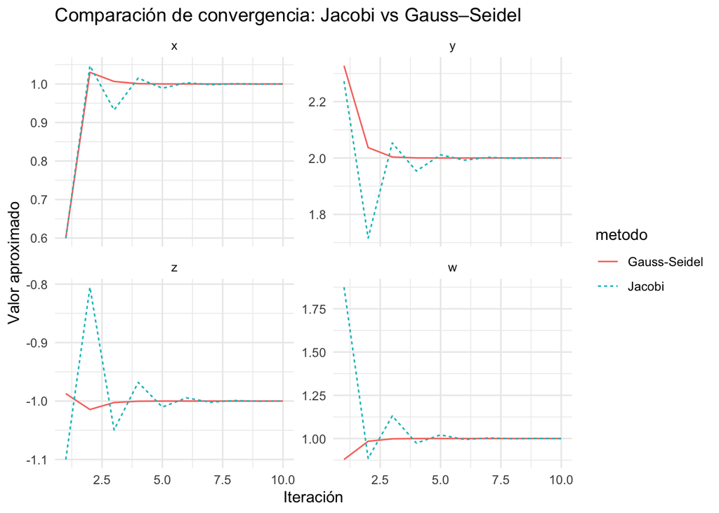

```r
if (!require(ggplot2)) install.packages("ggplot2", dependencies=TRUE)
library(ggplot2)


df_jacobi <- as.data.frame(jacobi_result)
df_jacobi$iter <- 1:nrow(df_jacobi)
df_jacobi$metodo <- "Jacobi"

df_gs <- as.data.frame(gs_result)
df_gs$iter <- 1:nrow(df_gs)
df_gs$metodo <- "Gauss-Seidel"

df_total <- rbind(df_jacobi, df_gs)
df_melt <- reshape2::melt(df_total, id.vars = c("iter", "metodo"))

## Graficar
ggplot(df_melt, aes(x = iter, y = value, color = metodo, linetype = metodo)) +
  geom_line() +
  facet_wrap(~variable, scales = "free_y") +
  labs(title = "Comparación de convergencia: Jacobi vs Gauss–Seidel",
       x = "Iteración", y = "Valor aproximado") +
  theme_minimal()
```

#### 12.- Comparación de Jacobi, Gauss-Seidel y SOR ## Aplique el método SOR con ω = 1.25 al mismo sistema y compare las tres trayectorias de convergencia.

```r
A <- matrix(c(10, -1, 2, 0,
              -1, 11, -1, 3,
              2, -1, 10, -1,
              0, 3, -1, 8), nrow = 4, byrow = TRUE)
b <- c(6, 25, -11, 15)
x0 <- c(0, 0, 0, 0)
```

```r
## Jacobi
jacobi <- function(A, b, x0, iter) {
  n <- length(b)
  x_old <- x0
  hist <- matrix(0, nrow = iter, ncol = n)

  for (k in 1:iter) {
    x_new <- numeric(n)
    for (i in 1:n) {
      suma <- sum(A[i, -i] * x_old[-i])
      x_new[i] <- (b[i] - suma) / A[i, i]
    }
    x_old <- x_new
    hist[k, ] <- x_new
  }
  return(hist)
}

## Gauss-Seidel
gauss_seidel <- function(A, b, x0, iter) {
  n <- length(b)
  x <- x0
  hist <- matrix(0, nrow = iter, ncol = n)

  for (k in 1:iter) {
    for (i in 1:n) {
      suma1 <- if (i > 1) sum(A[i, 1:(i-1)] * x[1:(i-1)]) else 0
      suma2 <- if (i < n) sum(A[i, (i+1):n] * x0[(i+1):n]) else 0
      x[i] <- (b[i] - suma1 - suma2) / A[i, i]
    }
    x0 <- x
    hist[k, ] <- x
  }
  return(hist)
}

## SOR
sor <- function(A, b, x0, omega, iter) {
  n <- length(b)
  x <- x0
  hist <- matrix(0, nrow = iter, ncol = n)

  for (k in 1:iter) {
    for (i in 1:n) {
      suma1 <- if (i > 1) sum(A[i, 1:(i-1)] * x[1:(i-1)]) else 0
      suma2 <- if (i < n) sum(A[i, (i+1):n] * x0[(i+1):n]) else 0
      x_new_i <- (b[i] - suma1 - suma2) / A[i, i]
      x[i] <- (1 - omega) * x0[i] + omega * x_new_i
    }
    x0 <- x
    hist[k, ] <- x
  }
  return(hist)
}
```

```r
iter <- 15  ## número de iteraciones

jacobi_res <- jacobi(A, b, x0, iter)
gs_res <- gauss_seidel(A, b, x0, iter)
sor_res <- sor(A, b, x0, omega = 1.25, iter)
```

```r
library(knitr)
df <- data.frame(
  Iteracion = 1:iter,
  Jacobi_x = round(jacobi_res[,1], 5),
  GS_x = round(gs_res[,1], 5),
  SOR_x = round(sor_res[,1], 5),
  Jacobi_y = round(jacobi_res[,2], 5),
  GS_y = round(gs_res[,2], 5),
  SOR_y = round(sor_res[,2], 5),
  Jacobi_z = round(jacobi_res[,3], 5),
  GS_z = round(gs_res[,3], 5),
  SOR_z = round(sor_res[,3], 5),
  Jacobi_w = round(jacobi_res[,4], 5),
  GS_w = round(gs_res[,4], 5),
  SOR_w = round(sor_res[,4], 5)
)

kable(df, caption = "Comparación de valores por iteración para Jacobi, GS y SOR")
```

Comparación de valores por iteración para Jacobi, GS y SOR

| Iteracion | Jacobi_x | GS_x | SOR_x | Jacobi_y | GS_y | SOR_y | Jacobi_z | GS_z | SOR_z | Jacobi_w | GS_w | SOR_w |
| --- | --- | --- | --- | --- | --- | --- | --- | --- | --- | --- | --- | --- |
| 1 | 0.60000 | 0.60000 | 0.75000 | 2.27273 | 2.32727 | 2.92614 | -1.10000 | -0.98727 | -1.19673 | 1.87500 | 0.87886 | 0.78513 |
| 2 | 1.04727 | 1.03018 | 1.22745 | 1.71591 | 2.03694 | 1.84521 | -0.80523 | -1.01446 | -1.05389 | 0.88523 | 0.98434 | 1.11786 |
| 3 | 0.93264 | 1.00659 | 0.93726 | 2.05331 | 2.00356 | 1.98527 | -1.04934 | -1.00253 | -0.95795 | 1.13088 | 0.99835 | 0.98401 |
| 4 | 1.01520 | 1.00086 | 1.00333 | 1.95370 | 2.00030 | 2.01429 | -0.96811 | -1.00031 | -1.01156 | 0.97384 | 0.99985 | 0.99549 |
| 5 | 0.98899 | 1.00009 | 1.00384 | 2.01141 | 2.00002 | 1.99709 | -1.01029 | -1.00003 | -0.99900 | 1.02135 | 0.99999 | 1.00265 |
| 6 | 1.00320 | 1.00001 | 0.99842 | 1.99224 | 2.00000 | 1.99976 | -0.99452 | -1.00000 | -0.99956 | 0.99443 | 1.00000 | 0.99952 |
| 7 | 0.99813 | 1.00000 | 1.00025 | 2.00231 | 2.00000 | 2.00030 | -1.00197 | -1.00000 | -1.00020 | 1.00359 | 1.00000 | 0.99995 |
| 8 | 1.00063 | 1.00000 | 1.00002 | 1.99867 | 2.00000 | 1.99992 | -0.99904 | -1.00000 | -0.99997 | 0.99889 | 1.00000 | 1.00005 |
| 9 | 0.99967 | 1.00000 | 0.99998 | 2.00045 | 2.00000 | 2.00000 | -1.00037 | -1.00000 | -0.99999 | 1.00062 | 1.00000 | 0.99999 |
| 10 | 1.00012 | 1.00000 | 1.00000 | 1.99977 | 2.00000 | 2.00001 | -0.99983 | -1.00000 | -1.00000 | 0.99979 | 1.00000 | 1.00000 |
| 11 | 0.99994 | 1.00000 | 1.00000 | 2.00008 | 2.00000 | 2.00000 | -1.00007 | -1.00000 | -1.00000 | 1.00011 | 1.00000 | 1.00000 |
| 12 | 1.00002 | 1.00000 | 1.00000 | 1.99996 | 2.00000 | 2.00000 | -0.99997 | -1.00000 | -1.00000 | 0.99996 | 1.00000 | 1.00000 |
| 13 | 0.99999 | 1.00000 | 1.00000 | 2.00002 | 2.00000 | 2.00000 | -1.00001 | -1.00000 | -1.00000 | 1.00002 | 1.00000 | 1.00000 |
| 14 | 1.00000 | 1.00000 | 1.00000 | 1.99999 | 2.00000 | 2.00000 | -0.99999 | -1.00000 | -1.00000 | 0.99999 | 1.00000 | 1.00000 |
| 15 | 1.00000 | 1.00000 | 1.00000 | 2.00000 | 2.00000 | 2.00000 | -1.00000 | -1.00000 | -1.00000 | 1.00000 | 1.00000 | 1.00000 |

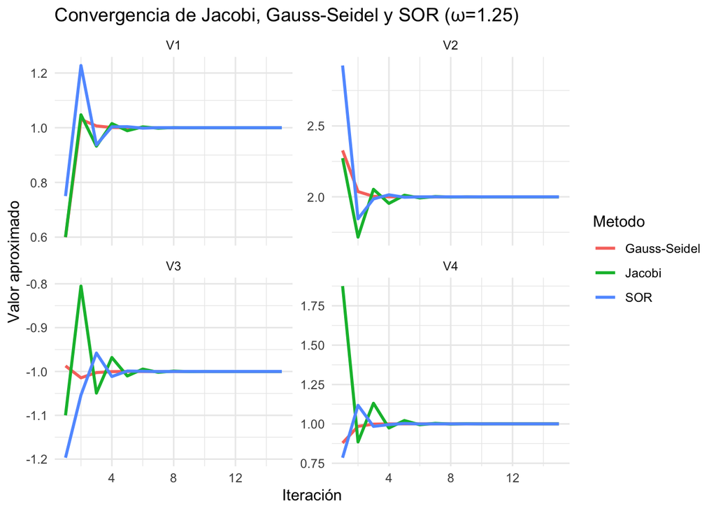

```r
library(ggplot2)
library(reshape2)

## Convertir datos a formato largo para ggplot
to_df <- function(mat, metodo) {
  df <- as.data.frame(mat)
  df$Iteracion <- 1:nrow(df)
  df$Metodo <- metodo
  df_melt <- melt(df, id.vars = c("Iteracion", "Metodo"))
  return(df_melt)
}

df_jacobi <- to_df(jacobi_res, "Jacobi")
df_gs <- to_df(gs_res, "Gauss-Seidel")
df_sor <- to_df(sor_res, "SOR")

df_total <- rbind(df_jacobi, df_gs, df_sor)

ggplot(df_total, aes(x = Iteracion, y = value, color = Metodo)) +
  geom_line(size = 1) +
  facet_wrap(~variable, scales = "free_y") +
  labs(title = "Convergencia de Jacobi, Gauss-Seidel y SOR (ω=1.25)",
       y = "Valor aproximado", x = "Iteración") +
  theme_minimal()
```

#### 14.- Código ejemplo completo para encontrar ω óptimo

```r
## Matriz y vector del sistema
A <- matrix(c(10, -1, 2, 0,
              -1, 11, -1, 3,
              2, -1, 10, -1,
              0, 3, -1, 8), nrow = 4, byrow = TRUE)
b <- c(6, 25, -11, 15)
x0 <- rep(0, 4)

## Función SOR del código anterior
sor <- function(A, b, x0, omega, iter) {
  n <- length(b)
  x <- x0
  for (k in 1:iter) {
    for (i in 1:n) {
      suma1 <- if (i > 1) sum(A[i, 1:(i-1)] * x[1:(i-1)]) else 0
      suma2 <- if (i < n) sum(A[i, (i+1):n] * x0[(i+1):n]) else 0
      x_new_i <- (b[i] - suma1 - suma2) / A[i, i]
      x[i] <- (1 - omega) * x0[i] + omega * x_new_i
    }
    x0 <- x
  }
  return(x)
}

## Solución exacta para comparar (usamos solve)
x_exact <- solve(A, b)

## Probar valores omega de 1 a 2 en pasos de 0.05
omega_vals <- seq(1, 2, by = 0.05)
iter <- 50  ## número fijo de iteraciones para comparar

## Almacenar errores
errors <- numeric(length(omega_vals))

for (i in seq_along(omega_vals)) {
  omega <- omega_vals[i]
  x_approx <- sor(A, b, x0, omega, iter)
  errors[i] <- sqrt(sum((x_approx - x_exact)^2))  ## norma euclidiana del error
}

## Mostrar resultados ordenados por error
resultado <- data.frame(omega = omega_vals, error = errors)
resultado_ordenado <- resultado[order(resultado$error), ]
print(head(resultado_ordenado, 5))
```

```
##   omega error
## 1  1.00     0
## 2  1.05     0
## 3  1.10     0
## 4  1.15     0
## 5  1.20     0
```

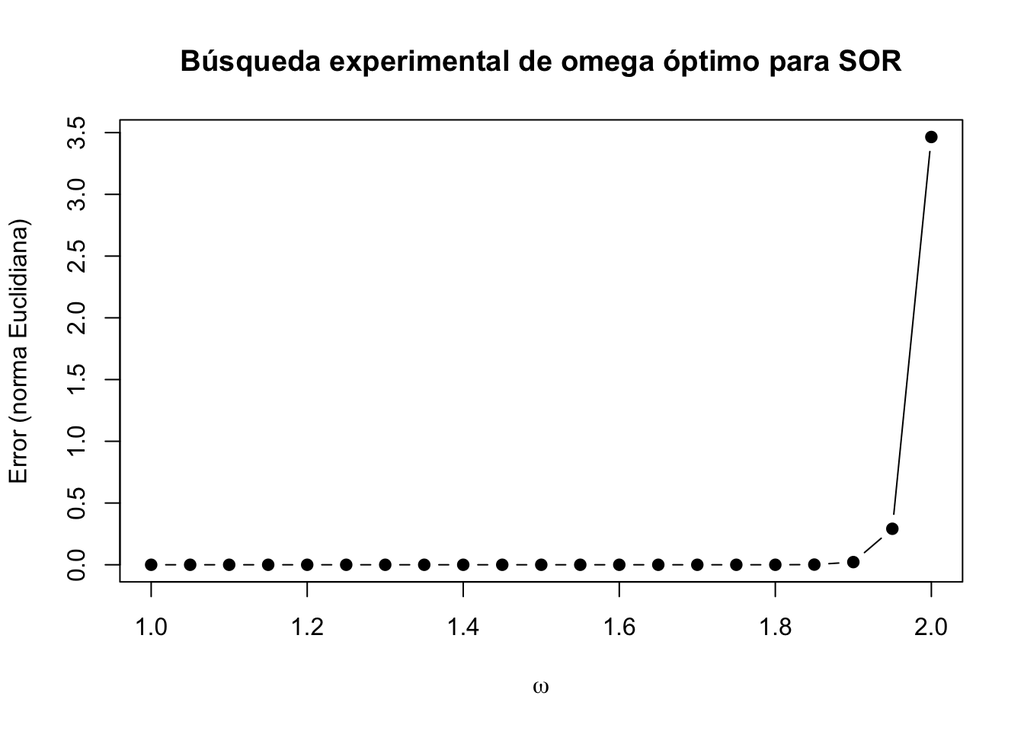

```r
## Graficar error vs omega
plot(resultado$omega, resultado$error, type = "b", pch = 19,
     xlab = expression(omega), ylab = "Error (norma Euclidiana)",
     main = "Búsqueda experimental de omega óptimo para SOR")
```

## PASO A PASO CON EL EJERCICIO 10

## Definir matriz A y vector b

```r
A <- matrix(c(10, -1, 2, 0,
              -1, 11, -1, 3,
              2, -1, 10, -1,
              0, 3, -1, 8), nrow = 4, byrow = TRUE)
b <- c(6, 25, -11, 15)
x0 <- rep(0, 4)  ## vector inicial
```

## FUNCIÓN MÉTODO SOR

```r
sor <- function(A, b, x0, omega, iter) {
  n <- length(b)
  x <- x0
  for (k in 1:iter) {
    for (i in 1:n) {
      suma1 <- if (i > 1) sum(A[i, 1:(i-1)] * x[1:(i-1)]) else 0
      suma2 <- if (i < n) sum(A[i, (i+1):n] * x0[(i+1):n]) else 0
      x_new_i <- (b[i] - suma1 - suma2) / A[i, i]
      x[i] <- (1 - omega) * x0[i] + omega * x_new_i
    }
    x0 <- x
  }
  return(x)
}
```

## SOLUCION EXACTA

```r
x_exact <- solve(A, b)
x_exact
```

```
## [1]  1  2 -1  1
```

## BUSQUEDA EXPERIMENTAL

```r
omega_vals <- seq(1, 2, by = 0.05)
iter <- 50
errors <- numeric(length(omega_vals))

for (i in seq_along(omega_vals)) {
  omega <- omega_vals[i]
  x_approx <- sor(A, b, x0, omega, iter)
  errors[i] <- sqrt(sum((x_approx - x_exact)^2))  ## error Euclidiano
}

resultado <- data.frame(Omega = omega_vals, Error = errors)
resultado_ordenado <- resultado[order(resultado$Error), ]
resultado_ordenado[1:5, ]
```

```
##   Omega Error
## 1  1.00     0
## 2  1.05     0
## 3  1.10     0
## 4  1.15     0
## 5  1.20     0
```

## GRAFICO

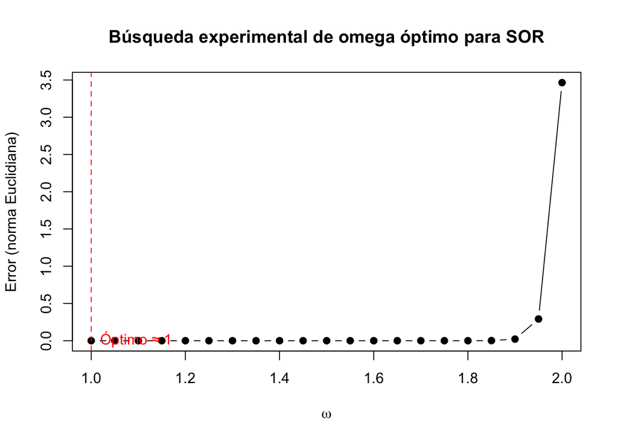

```r
plot(resultado$Omega, resultado$Error, type = "b", pch = 19,
     xlab = expression(omega), ylab = "Error (norma Euclidiana)",
     main = "Búsqueda experimental de omega óptimo para SOR")
abline(v = resultado_ordenado$Omega[1], col = "red", lty = 2)
text(resultado_ordenado$Omega[1], min(resultado$Error),
     labels = paste0("Óptimo ≈ ", round(resultado_ordenado$Omega[1], 3)),
     pos = 4, col = "red")
```

#### 13.- Escriba la matriz de iteracion TJ y el vector cJ del metodo de Jacobi para el sistema.

```r
A <- matrix(c(4, 1,
              1, 3), nrow = 2, byrow = TRUE)
b <- c(9, 7)
```

## Matriz de iteración Tj y vector Cj

```r
D <- diag(diag(A))

L <- A
L[upper.tri(L, diag = TRUE)] <- 0

U <- A
U[lower.tri(U, diag = TRUE)] <- 0

D_inv <- solve(D)

T_J <- -D_inv %*% (L + U)
c_J <- D_inv %*% b

T_J
```

```
##            [,1]  [,2]
## [1,]  0.0000000 -0.25
## [2,] -0.3333333  0.00
```

```r
c_J
```

```
##          [,1]
## [1,] 2.250000
## [2,] 2.333333
```

## Cálculo del radio espectral

```r
eigenvals <- eigen(T_J)$values
rho_TJ <- max(abs(eigenvals))
rho_TJ
```

```
## [1] 0.2886751
```

## Verificación de convergencia

```r
if (rho_TJ < 1) {
  cat("El método de Jacobi converge porque rho(T_J) =", round(rho_TJ, 4), "< 1")
} else {
  cat("El método de Jacobi NO converge porque rho(T_J) =", round(rho_TJ, 4), "≥ 1")
}
```

```
## El método de Jacobi converge porque rho(T_J) = 0.2887 < 1
```

#### 15.- Genere una matriz aleatoria sim´etrica definida positiva 5 × 5 en R y resuelva Ax = b:

```r
set.seed(123)  ## Para reproducibilidad

n <- 5

## Generar matriz aleatoria de enteros entre -10 y 10
M_int <- matrix(sample(-10:10, n^2, replace=TRUE), n, n)

## Construir matriz simétrica definida positiva sumando M_int^T * M_int + identidad
A <- t(M_int) %*% M_int + diag(n)

## El resultado es simétrico, definida positiva y con entradas enteras

## Vector b con enteros también (por ejemplo entre -10 y 10)
b <- sample(-10:10, n, replace=TRUE)

## Mostrar matriz y vector
A
```

```
##      [,1] [,2] [,3] [,4] [,5]
## [1,]  155  -65  101  -87   82
## [2,]  -65  176 -111   35   15
## [3,]  101 -111  178  -23   32
## [4,]  -87   35  -23  135 -120
## [5,]   82   15   32 -120  162
```

```r
b
```

```
## [1]  1  4 -1  2 -4
```

## Implementación método Gauss-Seidel

```r
gauss_seidel <- function(A, b, x0=NULL, iterations=20) {
  n <- length(b)
  if (is.null(x0)) x0 <- rep(0, n)
  x <- x0
  for (k in 1:iterations) {
    for (i in 1:n) {
      sum1 <- if(i > 1) sum(A[i, 1:(i-1)] * x[1:(i-1)]) else 0
      sum2 <- if(i < n) sum(A[i, (i+1):n] * x[(i+1):n]) else 0
      x[i] <- (b[i] - sum1 - sum2) / A[i, i]
    }
  }
  return(x)
}
```

## Usando factorizacion LU

```r
library(Matrix)

start_lu <- Sys.time()
lu_decomp <- lu(Matrix(A))
x_lu <- solve(lu_decomp, b)
end_lu <- Sys.time()

tiempo_lu <- end_lu - start_lu
tiempo_lu
```

```
## Time difference of 0.003161907 secs
```

## Usando factorizacion de Cholesky

```r
start_chol <- Sys.time()
chol_decomp <- chol(A)
x_chol <- backsolve(chol_decomp, forwardsolve(t(chol_decomp), b))
end_chol <- Sys.time()

tiempo_chol <- end_chol - start_chol
tiempo_chol
```

```
## Time difference of 0.001082897 secs
```

## Usando Gauss–Seidel con 20 iteraciones

```r
start_gs <- Sys.time()
x_gs <- gauss_seidel(A, b, iterations=20)
end_gs <- Sys.time()

tiempo_gs <- end_gs - start_gs
tiempo_gs
```

```
## Time difference of 0.009948015 secs
```

## Comparacion

```r
x_exact <- solve(A, b)

error_lu <- norm(x_lu - x_exact, type="2") / norm(x_exact, type="2")
error_chol <- norm(x_chol - x_exact, type="2") / norm(x_exact, type="2")
error_gs <- norm(x_gs - x_exact, type="2") / norm(x_exact, type="2")

data.frame(
  Metodo = c("LU", "Cholesky", "Gauss-Seidel"),
  Tiempo_seg = c(as.numeric(tiempo_lu, units="secs"),
                 as.numeric(tiempo_chol, units="secs"),
                 as.numeric(tiempo_gs, units="secs")),
  Error_relativo = c(error_lu, error_chol, error_gs)
)
```

```
##         Metodo  Tiempo_seg Error_relativo
## 1           LU 0.003161907   0.000000e+00
## 2     Cholesky 0.001082897   2.163838e-16
## 3 Gauss-Seidel 0.009948015   9.129486e-02
```

# Raíces de funciones

## Método de Bisección

```r
biseccion <- function(f, a, b, n_iter = 8) {
  # Verifica cambio de signo
  fa <- f(a)
  fb <- f(b)
  if (fa * fb > 0) {
    warning(paste("El intervalo [", a, ",", b, "] no presenta cambio de signo (f(a)*f(b) =", fa*fb, ")."))
  }

  tabla <- data.frame(
    k = numeric(0),
    a = numeric(0),
    b = numeric(0),
    c = numeric(0),
    f_a = numeric(0),
    f_b = numeric(0),
    f_c = numeric(0),
    signo = character(0),
    error = numeric(0)
  )

  for (k in 1:n_iter) {
    c <- (a + b) / 2
    fa <- f(a)
    fb <- f(b)
    fc <- f(c)

    signo <- ifelse(fa * fc < 0, "<0", ">0")
    error <- abs(b - a)

    tabla <- rbind(tabla, data.frame(k, a, b, c, f_a = fa, f_b = fb, f_c = fc, signo, error))

    if (fa * fc < 0) {
      b <- c
    } else {
      a <- c
    }
  }
  return(tabla)
}
```

### Lista completa de funciones y sus intervalos

```
##
##
## ### 1. f(x)=x^2 - 5
##   k        a        b        c          f_a        f_b          f_c signo
## 1 1 2.000000 3.000000 2.500000 -1.000000000 4.00000000  1.250000000    <0
## 2 2 2.000000 2.500000 2.250000 -1.000000000 1.25000000  0.062500000    <0
## 3 3 2.000000 2.250000 2.125000 -1.000000000 0.06250000 -0.484375000    >0
## 4 4 2.125000 2.250000 2.187500 -0.484375000 0.06250000 -0.214843750    >0
## 5 5 2.187500 2.250000 2.218750 -0.214843750 0.06250000 -0.077148438    >0
## 6 6 2.218750 2.250000 2.234375 -0.077148438 0.06250000 -0.007568359    >0
## 7 7 2.234375 2.250000 2.242188 -0.007568359 0.06250000  0.027404785    <0
## 8 8 2.234375 2.242188 2.238281 -0.007568359 0.02740479  0.009902954    <0
##       error
## 1 1.0000000
## 2 0.5000000
## 3 0.2500000
## 4 0.1250000
## 5 0.0625000
## 6 0.0312500
## 7 0.0156250
## 8 0.0078125
```

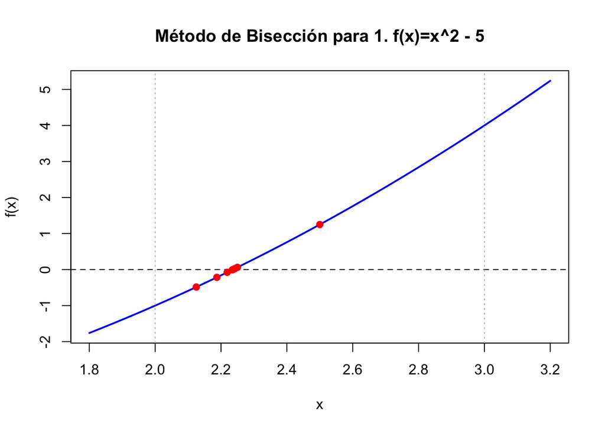

```
##
##
## ### 2. f(x)=x^3 - 4x + 1
##   k    a         b         c      f_a         f_b           f_c signo     error
## 1 1 0.00 1.0000000 0.5000000 1.000000 -2.00000000 -0.8750000000    <0 1.0000000
## 2 2 0.00 0.5000000 0.2500000 1.000000 -0.87500000  0.0156250000    >0 0.5000000
## 3 3 0.25 0.5000000 0.3750000 0.015625 -0.87500000 -0.4472656250    <0 0.2500000
## 4 4 0.25 0.3750000 0.3125000 0.015625 -0.44726562 -0.2194824219    <0 0.1250000
## 5 5 0.25 0.3125000 0.2812500 0.015625 -0.21948242 -0.1027526855    <0 0.0625000
## 6 6 0.25 0.2812500 0.2656250 0.015625 -0.10275269 -0.0437583923    <0 0.0312500
## 7 7 0.25 0.2656250 0.2578125 0.015625 -0.04375839 -0.0141139030    <0 0.0156250
## 8 8 0.25 0.2578125 0.2539062 0.015625 -0.01411390  0.0007439256    >0 0.0078125
```

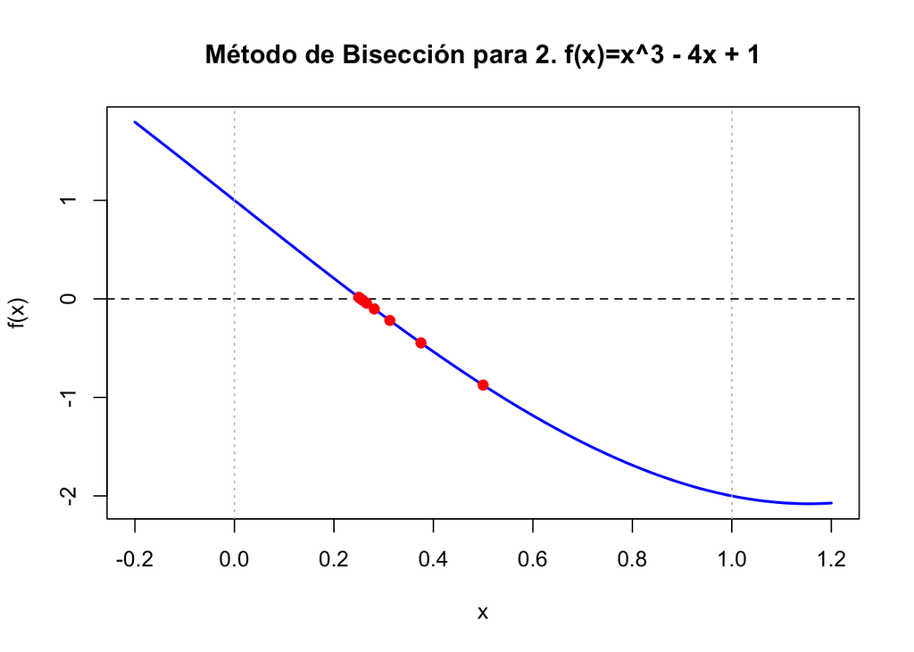

```
##
##
## ### 3. f(x)=x^4 - 8x + 2
```

```
##   k        a         b         c       f_a        f_b         f_c signo
## 1 1 0.000000 3.0000000 1.5000000 2.0000000 59.0000000 -4.93750000    <0
## 2 2 0.000000 1.5000000 0.7500000 2.0000000 -4.9375000 -3.68359375    <0
## 3 3 0.000000 0.7500000 0.3750000 2.0000000 -3.6835938 -0.98022461    <0
## 4 4 0.000000 0.3750000 0.1875000 2.0000000 -0.9802246  0.50123596    >0
## 5 5 0.187500 0.3750000 0.2812500 0.5012360 -0.9802246 -0.24374294    <0
## 6 6 0.187500 0.2812500 0.2343750 0.5012360 -0.2437429  0.12801749    >0
## 7 7 0.234375 0.2812500 0.2578125 0.1280175 -0.2437429 -0.05808210    <0
## 8 8 0.234375 0.2578125 0.2460938 0.1280175 -0.0580821  0.03491777    >0
##       error
## 1 3.0000000
## 2 1.5000000
## 3 0.7500000
## 4 0.3750000
## 5 0.1875000
## 6 0.0937500
## 7 0.0468750
## 8 0.0234375
```

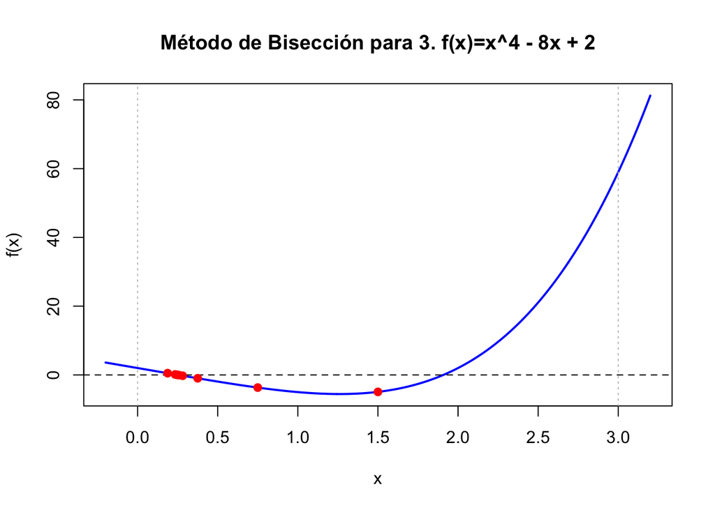

```
##
##
## ### 4. f(x)=exp(-x) - x^2
##   k        a       b         c          f_a         f_b           f_c signo
## 1 1 0.000000 2.00000 1.0000000 1.0000000000 -3.86466472 -0.6321205588    <0
## 2 2 0.000000 1.00000 0.5000000 1.0000000000 -0.63212056  0.3565306597    >0
## 3 3 0.500000 1.00000 0.7500000 0.3565306597 -0.63212056 -0.0901334473    <0
## 4 4 0.500000 0.75000 0.6250000 0.3565306597 -0.09013345  0.1446364285    >0
## 5 5 0.625000 0.75000 0.6875000 0.1446364285 -0.09013345  0.0301753280    >0
## 6 6 0.687500 0.75000 0.7187500 0.0301753280 -0.09013345 -0.0292404858    <0
## 7 7 0.687500 0.71875 0.7031250 0.0301753280 -0.02924049  0.0006511313    >0
## 8 8 0.703125 0.71875 0.7109375 0.0006511313 -0.02924049 -0.0142486319    <0
##      error
## 1 2.000000
## 2 1.000000
## 3 0.500000
## 4 0.250000
## 5 0.125000
## 6 0.062500
## 7 0.031250
## 8 0.015625
```

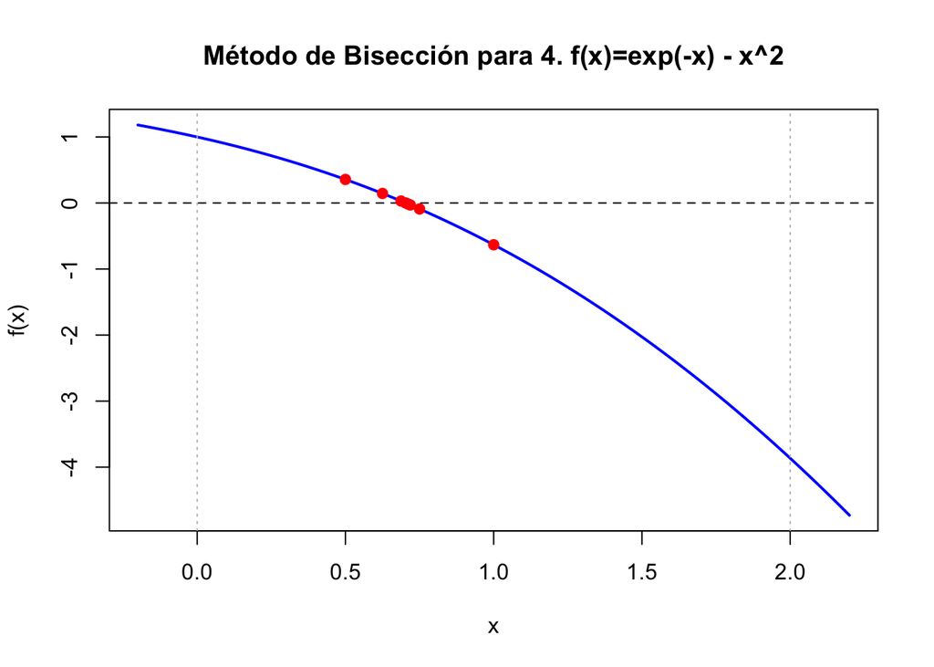

```
##
##
## ### 5. f(x)=cos(x) - x^2
##   k         a        b         c         f_a          f_b           f_c signo
## 1 1 0.0000000 1.000000 0.5000000 1.000000000 -0.459697694  0.6275825619    >0
## 2 2 0.5000000 1.000000 0.7500000 0.627582562 -0.459697694  0.1691888689    >0
## 3 3 0.7500000 1.000000 0.8750000 0.169188869 -0.459697694 -0.1246281418    <0
## 4 4 0.7500000 0.875000 0.8125000 0.169188869 -0.124628142  0.0275293122    >0
## 5 5 0.8125000 0.875000 0.8437500 0.027529312 -0.124628142 -0.0472483349    <0
## 6 6 0.8125000 0.843750 0.8281250 0.027529312 -0.047248335 -0.0095328213    <0
## 7 7 0.8125000 0.828125 0.8203125 0.027529312 -0.009532821  0.0090800933    >0
## 8 8 0.8203125 0.828125 0.8242188 0.009080093 -0.009532821 -0.0002059239    <0
##       error
## 1 1.0000000
## 2 0.5000000
## 3 0.2500000
## 4 0.1250000
## 5 0.0625000
## 6 0.0312500
## 7 0.0156250
## 8 0.0078125
```

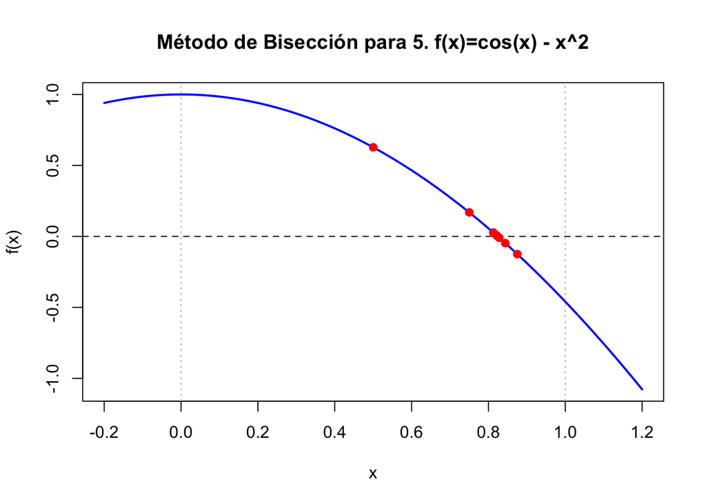

```
##
##
## ### 6. f(x)=3x^2 - 7x - 2
##   k          a     b          c         f_a     f_b          f_c signo
## 1 1 -1.0000000  0.00 -0.5000000 8.000000000 -2.0000  2.250000000    >0
## 2 2 -0.5000000  0.00 -0.2500000 2.250000000 -2.0000 -0.062500000    <0
## 3 3 -0.5000000 -0.25 -0.3750000 2.250000000 -0.0625  1.046875000    >0
## 4 4 -0.3750000 -0.25 -0.3125000 1.046875000 -0.0625  0.480468750    >0
## 5 5 -0.3125000 -0.25 -0.2812500 0.480468750 -0.0625  0.206054688    >0
## 6 6 -0.2812500 -0.25 -0.2656250 0.206054688 -0.0625  0.071044922    >0
## 7 7 -0.2656250 -0.25 -0.2578125 0.071044922 -0.0625  0.004089355    >0
## 8 8 -0.2578125 -0.25 -0.2539062 0.004089355 -0.0625 -0.029251099    <0
##       error
## 1 1.0000000
## 2 0.5000000
## 3 0.2500000
## 4 0.1250000
## 5 0.0625000
## 6 0.0312500
## 7 0.0156250
## 8 0.0078125
```

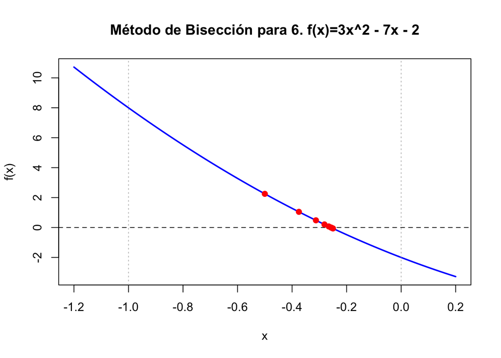

```
##
##
## ### 7. f(x)=-4x^2 + 5x + 6
##   k          a    b          c       f_a f_b      f_c signo     error
## 1 1 -1.0000000  0.0 -0.5000000 -3.000000 6.0 2.500000    <0 1.0000000
## 2 2 -1.0000000 -0.5 -0.7500000 -3.000000 2.5 0.000000    >0 0.5000000
## 3 3 -0.7500000 -0.5 -0.6250000  0.000000 2.5 1.312500    >0 0.2500000
## 4 4 -0.6250000 -0.5 -0.5625000  1.312500 2.5 1.921875    >0 0.1250000
## 5 5 -0.5625000 -0.5 -0.5312500  1.921875 2.5 2.214844    >0 0.0625000
## 6 6 -0.5312500 -0.5 -0.5156250  2.214844 2.5 2.358398    >0 0.0312500
## 7 7 -0.5156250 -0.5 -0.5078125  2.358398 2.5 2.429443    >0 0.0156250
## 8 8 -0.5078125 -0.5 -0.5039062  2.429443 2.5 2.464783    >0 0.0078125
```

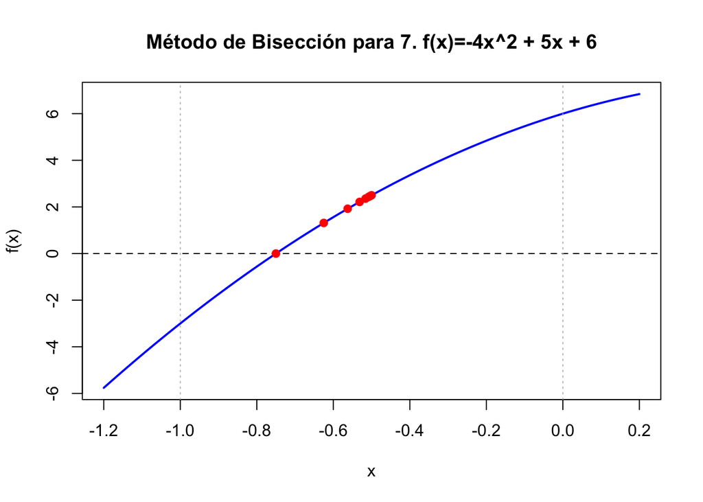

```
##
##
## ### 8. f(x)=2x^2 + 3x - 5
##   k        a b        c       f_a f_b      f_c signo    error
## 1 1 0.000000 2 1.000000 -5.000000   9 0.000000    >0 2.000000
## 2 2 1.000000 2 1.500000  0.000000   9 4.000000    >0 1.000000
## 3 3 1.500000 2 1.750000  4.000000   9 6.375000    >0 0.500000
## 4 4 1.750000 2 1.875000  6.375000   9 7.656250    >0 0.250000
## 5 5 1.875000 2 1.937500  7.656250   9 8.320312    >0 0.125000
## 6 6 1.937500 2 1.968750  8.320312   9 8.658203    >0 0.062500
## 7 7 1.968750 2 1.984375  8.658203   9 8.828613    >0 0.031250
## 8 8 1.984375 2 1.992188  8.828613   9 8.914185    >0 0.015625
```

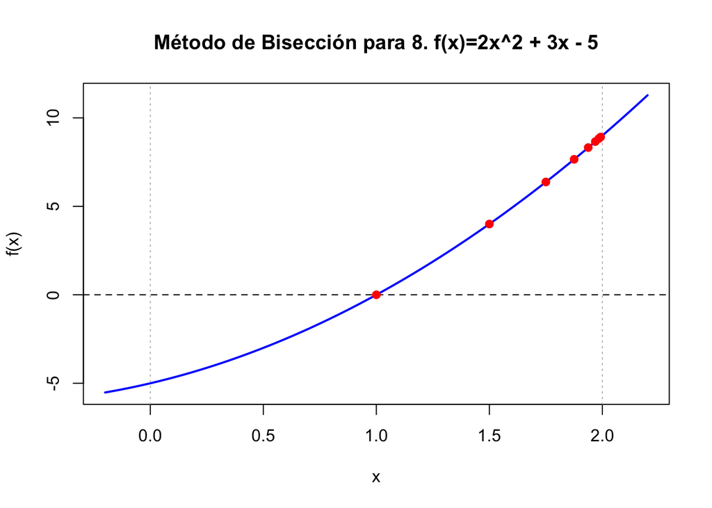

```
##
##
## ### 9. f(x)=x^3 - 5x + 1
##   k         a        b         c        f_a         f_b         f_c signo
## 1 1 0.0000000 1.000000 0.5000000 1.00000000 -3.00000000 -1.37500000    <0
## 2 2 0.0000000 0.500000 0.2500000 1.00000000 -1.37500000 -0.23437500    <0
## 3 3 0.0000000 0.250000 0.1250000 1.00000000 -0.23437500  0.37695312    >0
## 4 4 0.1250000 0.250000 0.1875000 0.37695312 -0.23437500  0.06909180    >0
## 5 5 0.1875000 0.250000 0.2187500 0.06909180 -0.23437500 -0.08328247    <0
## 6 6 0.1875000 0.218750 0.2031250 0.06909180 -0.08328247 -0.00724411    <0
## 7 7 0.1875000 0.203125 0.1953125 0.06909180 -0.00724411  0.03088808    >0
## 8 8 0.1953125 0.203125 0.1992188 0.03088808 -0.00724411  0.01181287    >0
##       error
## 1 1.0000000
## 2 0.5000000
## 3 0.2500000
## 4 0.1250000
## 5 0.0625000
## 6 0.0312500
## 7 0.0156250
## 8 0.0078125
```

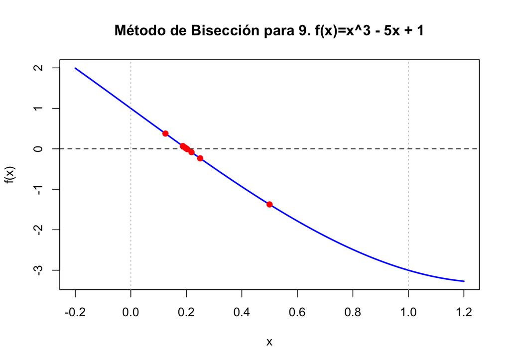

```
##
##
## ### 10. f(x)=x^4 - 6x^3 + 5x^2 + 8x - 4
##   k      a         b         c          f_a        f_b          f_c signo
## 1 1 0.0000 1.0000000 0.5000000 -4.000000000 4.00000000  0.562500000    <0
## 2 2 0.0000 0.5000000 0.2500000 -4.000000000 0.56250000 -1.777343750    >0
## 3 3 0.2500 0.5000000 0.3750000 -1.777343750 0.56250000 -0.593505859    >0
## 4 4 0.3750 0.5000000 0.4375000 -0.593505859 0.56250000 -0.008773804    >0
## 5 5 0.4375 0.5000000 0.4687500 -0.008773804 0.56250000  0.278931618    <0
## 6 6 0.4375 0.4687500 0.4531250 -0.008773804 0.27893162  0.135548651    <0
## 7 7 0.4375 0.4531250 0.4453125 -0.008773804 0.13554865  0.063498858    <0
## 8 8 0.4375 0.4453125 0.4414062 -0.008773804 0.06349886  0.027389631    <0
##       error
## 1 1.0000000
## 2 0.5000000
## 3 0.2500000
## 4 0.1250000
## 5 0.0625000
## 6 0.0312500
## 7 0.0156250
## 8 0.0078125
```

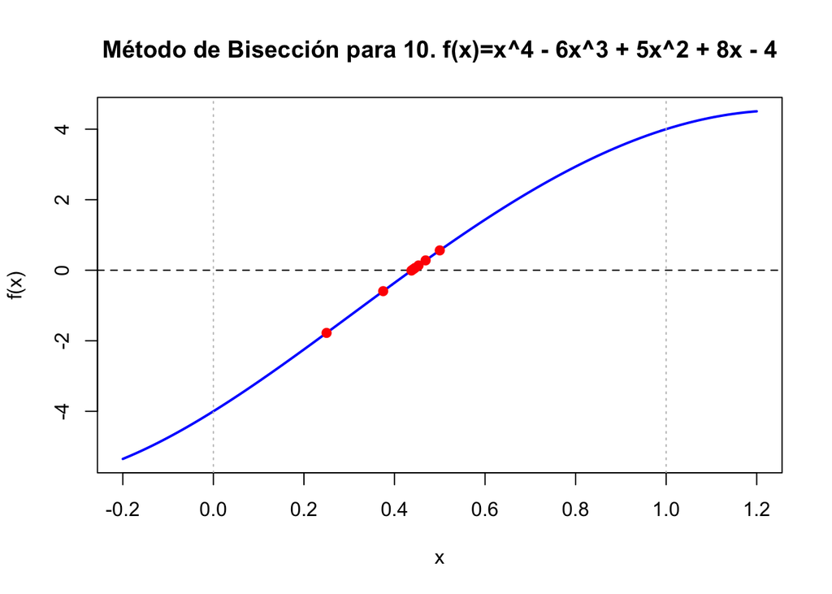

```
##
##
## ### 11. f(x)=-2x^4 + 4x^3 + 6x^2 - 3x + 2
##   k      a         b         c          f_a       f_b         f_c signo
## 1 1 -2.000 -1.000000 -1.500000 -32.00000000 5.0000000 -3.62500000    >0
## 2 2 -1.500 -1.000000 -1.250000  -3.62500000 5.0000000  2.42968750    <0
## 3 3 -1.500 -1.250000 -1.375000  -3.62500000 2.4296875 -0.07861328    >0
## 4 4 -1.375 -1.250000 -1.312500  -0.07861328 2.4296875  1.29440308    <0
## 5 5 -1.375 -1.312500 -1.343750  -0.07861328 1.2944031  0.63894463    <0
## 6 6 -1.375 -1.343750 -1.359375  -0.07861328 0.6389446  0.28809726    <0
## 7 7 -1.375 -1.359375 -1.367188  -0.07861328 0.2880973  0.10674619    <0
## 8 8 -1.375 -1.367188 -1.371094  -0.07861328 0.1067462  0.01457018    <0
##       error
## 1 1.0000000
## 2 0.5000000
## 3 0.2500000
## 4 0.1250000
## 5 0.0625000
## 6 0.0312500
## 7 0.0156250
## 8 0.0078125
```

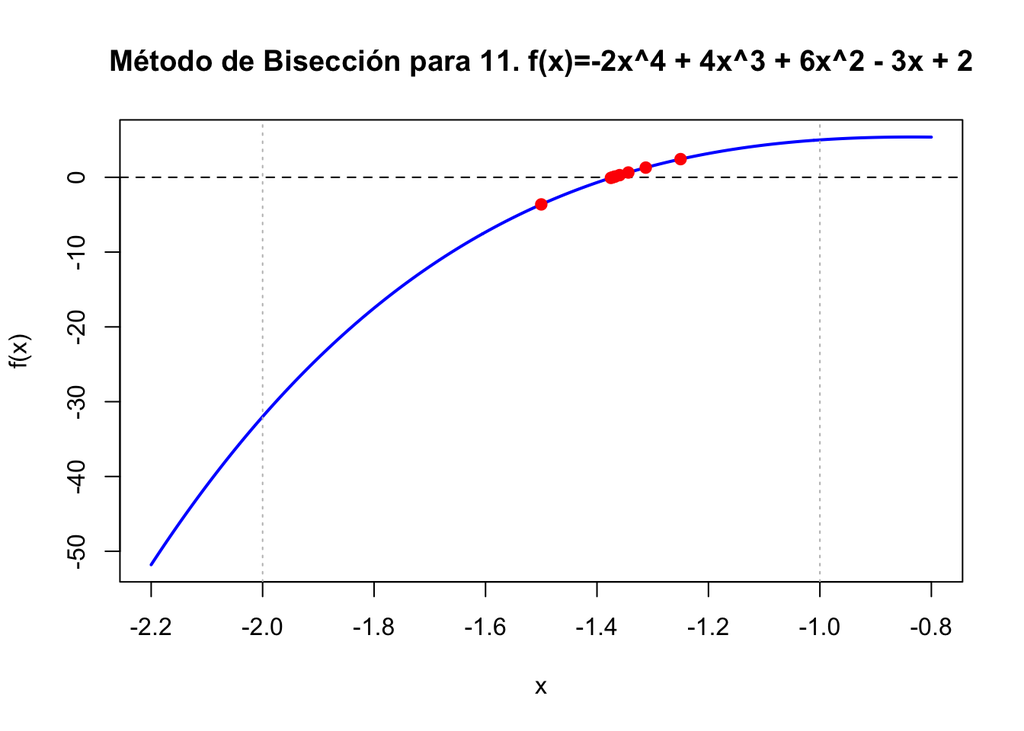

```
##
##
## ### 12. f(x)=2x^4 - x^3 - 7x^2 + 4x + 3
##   k          a       b          c          f_a        f_b          f_c signo
## 1 1 -1.0000000  0.0000 -0.5000000 -5.000000000 3.00000000 -0.500000000    >0
## 2 2 -0.5000000  0.0000 -0.2500000 -0.500000000 3.00000000  1.585937500    <0
## 3 3 -0.5000000 -0.2500 -0.3750000 -0.500000000 1.58593750  0.607910156    <0
## 4 4 -0.5000000 -0.3750 -0.4375000 -0.500000000 0.60791016  0.067169189    <0
## 5 5 -0.5000000 -0.4375 -0.4687500 -0.500000000 0.06716919 -0.213529587    >0
## 6 6 -0.4687500 -0.4375 -0.4531250 -0.213529587 0.06716919 -0.072404742    >0
## 7 7 -0.4531250 -0.4375 -0.4453125 -0.072404742 0.06716919 -0.002417319    >0
## 8 8 -0.4453125 -0.4375 -0.4414062 -0.002417319 0.06716919  0.032426864    <0
##       error
## 1 1.0000000
## 2 0.5000000
## 3 0.2500000
## 4 0.1250000
## 5 0.0625000
## 6 0.0312500
## 7 0.0156250
## 8 0.0078125
```

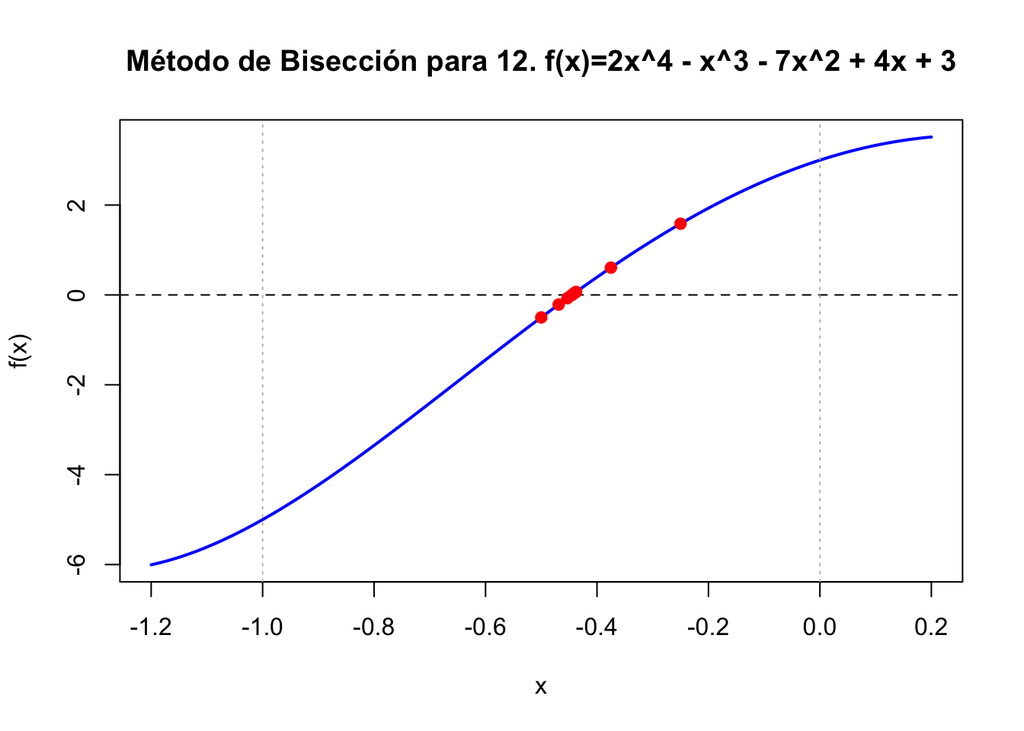

```
##
##
## ### 13. f(x)=x^4 + 2x^3 - 10x^2 - x + 5
##   k         a        b         c        f_a         f_b          f_c signo
## 1 1 0.0000000 1.000000 0.5000000 5.00000000 -3.00000000  2.312500000    >0
## 2 2 0.5000000 1.000000 0.7500000 2.31250000 -3.00000000 -0.214843750    <0
## 3 3 0.5000000 0.750000 0.6250000 2.31250000 -0.21484375  1.109619141    >0
## 4 4 0.6250000 0.750000 0.6875000 1.10961914 -0.21484375  0.459243774    >0
## 5 5 0.6875000 0.750000 0.7187500 0.45924377 -0.21484375  0.124726295    >0
## 6 6 0.7187500 0.750000 0.7343750 0.12472630 -0.21484375 -0.044483125    <0
## 7 7 0.7187500 0.734375 0.7265625 0.12472630 -0.04448313  0.040272538    >0
## 8 8 0.7265625 0.734375 0.7304688 0.04027254 -0.04448313 -0.002068434    <0
##       error
## 1 1.0000000
## 2 0.5000000
## 3 0.2500000
## 4 0.1250000
## 5 0.0625000
## 6 0.0312500
## 7 0.0156250
## 8 0.0078125
```

[6 more figures not shown]

```r
ejercicios <- list(
list(label="1. f(x)=x^2 - 5", f=function(x) x^2 - 5, a=2, b=3),
list(label="2. f(x)=x^3 - 4x + 1", f=function(x) x^3 - 4*x + 1, a=0, b=1),
list(label="3. f(x)=x^4 - 8x + 2", f=function(x) x^4 - 8*x + 2, a=0, b=3),
list(label="4. f(x)=exp(-x) - x^2", f=function(x) exp(-x) - x^2, a=0, b=2),
list(label="5. f(x)=cos(x) - x^2", f=function(x) cos(x) - x^2, a=0, b=1),
list(label="6. f(x)=3x^2 - 7x - 2", f=function(x) 3*x^2 - 7*x - 2, a=-1, b=0),
list(label="7. f(x)=-4x^2 + 5x + 6", f=function(x) -4*x^2 + 5*x + 6, a=-1, b=0),
list(label="8. f(x)=2x^2 + 3x - 5", f=function(x) 2*x^2 + 3*x - 5, a=0, b=2),
list(label="9. f(x)=x^3 - 5x + 1", f=function(x) x^3 - 5*x + 1, a=0, b=1),
list(label="10. f(x)=x^4 - 6x^3 + 5x^2 + 8x - 4", f=function(x) x^4 - 6*x^3 + 5*x^2 + 8*x - 4, a=0, b=1),
list(label="11. f(x)=-2x^4 + 4x^3 + 6x^2 - 3x + 2", f=function(x) -2*x^4 + 4*x^3 + 6*x^2 - 3*x + 2, a=-2, b=-1),
list(label="12. f(x)=2x^4 - x^3 - 7x^2 + 4x + 3", f=function(x) 2*x^4 - x^3 - 7*x^2 + 4*x + 3, a=-1, b=0),
list(label="13. f(x)=x^4 + 2x^3 - 10x^2 - x + 5", f=function(x) x^4 + 2*x^3 - 10*x^2 - x + 5, a=0, b=1),
list(label="14. f(x)=5*exp(0.6x - 1) - 3", f=function(x) 5*exp(0.6*x - 1) - 3, a=0, b=2),
list(label="15. f(x)=7 - 4*exp(-0.9x + 0.2)", f=function(x) 7 - 4*exp(-0.9*x + 0.2), a=-2, b=0),
list(label="16. f(x)=sin(2x) - x^2", f=function(x) sin(2*x) - x^2, a=1, b=2),
list(label="17. f(x)=(2x+1.4)*cos(3x + pi/4)", f=function(x) (2*x+1.4)*cos(3*x + pi/4), a=0.1, b=0.6),
list(label="18. f(x)=(-1.5x + 0.9)*sin(4x) - pi/6", f=function(x) (-1.5*x + 0.9)*sin(4*x) - pi/6, a=0.2, b=0.9)
)

# Cálculo y gráficos base

for (ej in ejercicios) {
cat("\n\n###", ej$label, "\n")

tabla <- biseccion(ej$f, ej$a, ej$b, 8)
print(tabla)

# Gráfica en base R

x_vals <- seq(ej$a - 0.2, ej$b + 0.2, length.out = 300)
y_vals <- sapply(x_vals, ej$f)

plot(x_vals, y_vals, type="l", col="blue", lwd=2,
main=paste("Método de Bisección para", ej$label),
xlab="x", ylab="f(x)")
abline(h=0, lty=2)
abline(v=c(ej$a, ej$b), col="gray", lty=3)
points(tabla$c, sapply(tabla$c, ej$f), col="red", pch=19)
}
```

## Método de la Secante

```
##
##
## Ejercicio 1
##   Iter x_prev x_curr f_xcurr x_next error
## 1    1      0      3       0      3     0
```

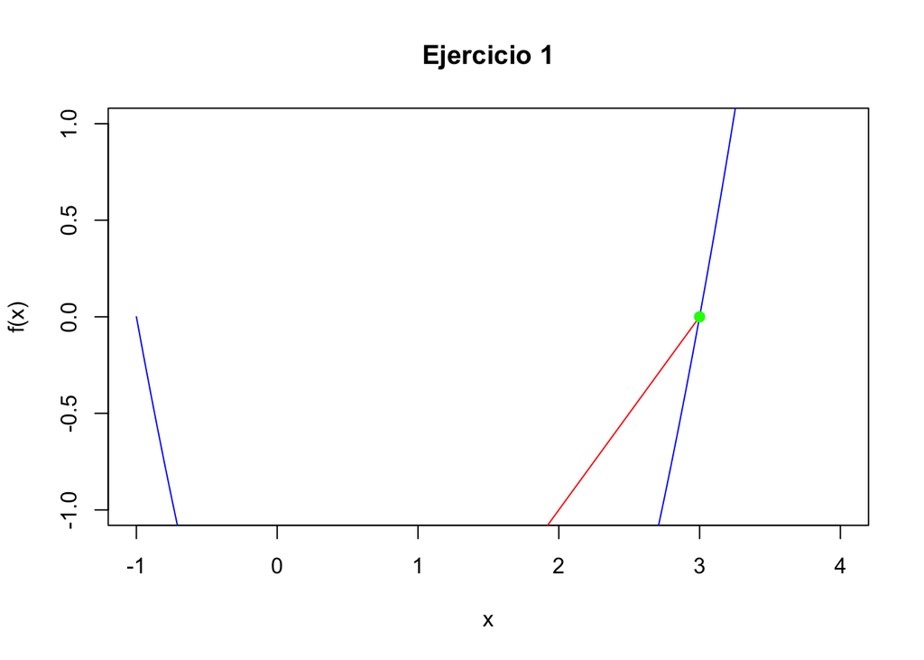

```
##
##
## Ejercicio 2
##   Iter    x_prev    x_curr       f_xcurr    x_next        error
## 1    1 0.0000000 2.0000000 -1.500000e+01 0.7500000 1.250000e+00
## 2    2 2.0000000 0.7500000  3.691406e+00 0.9968652 2.468652e-01
## 3    3 0.7500000 0.9968652  5.011731e-02 1.0002630 3.397758e-03
## 4    4 0.9968652 1.0002630 -4.207669e-03 0.9999998 2.631689e-04
## 5    5 1.0002630 0.9999998  3.309175e-06 1.0000000 2.068098e-07
```

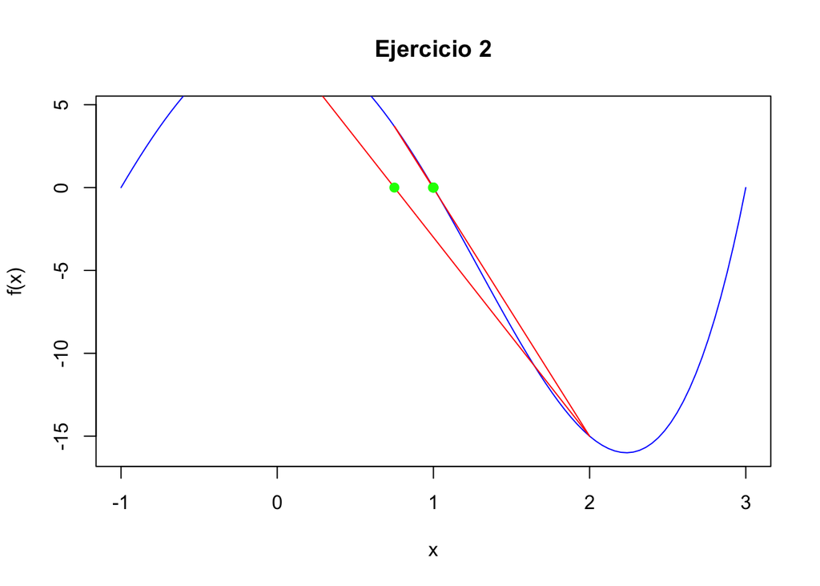

```
##
##
## Ejercicio 3
##   Iter    x_prev   x_curr      f_xcurr   x_next        error
## 1    1 -1.000000 2.000000 1.000000e+00 2.333333 3.333333e-01
## 2    2  2.000000 2.333333 2.222222e+00 1.727273 6.060606e-01
## 3    3  2.333333 1.727273 3.305785e-01 1.621359 1.059135e-01
## 4    4  1.727273 1.621359 1.508153e-01 1.532501 8.885792e-02
## 5    5  1.621359 1.532501 3.461397e-02 1.506032 2.646892e-02
## 6    6  1.532501 1.506032 6.105155e-03 1.500364 5.668313e-03
## 7    7  1.506032 1.500364 3.643279e-04 1.500004 3.597259e-04
## 8    8  1.500364 1.500004 4.336884e-06 1.500000 4.333691e-06
```

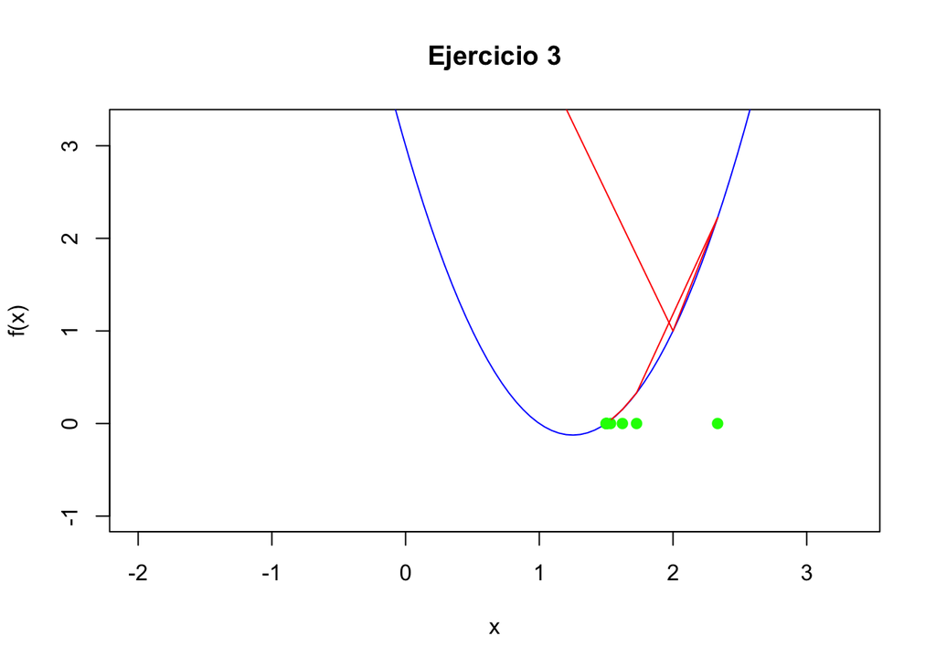

```
##
##
## Ejercicio 4
##    Iter     x_prev     x_curr       f_xcurr     x_next      error
## 1     1  -1.000000   3.000000   -13.0000000  -3.500000  6.5000000
## 2     2   3.000000  -3.500000   -48.7500000   5.363636  8.8636364
## 3     3  -3.500000   5.363636   -62.8512397 -34.142857 39.5064935
## 4     4   5.363636 -34.142857 -3631.7755102   6.059373 40.2022303
## 5     5 -34.142857   6.059373   -83.9105180   7.010196  0.9508225
## 6     6   6.059373   7.010196  -117.3877498   3.676141  3.3340546
## 7     7   7.010196   3.676141   -23.8374770   2.826593  0.8495480
## 8     8   3.676141   2.826593   -10.6625139   2.139053  0.6875403
## 9     9   2.826593   2.139053    -3.1704302   1.848106  0.2909469
## 10   10   2.139053   1.848106    -0.8540634   1.740832  0.1072745
```

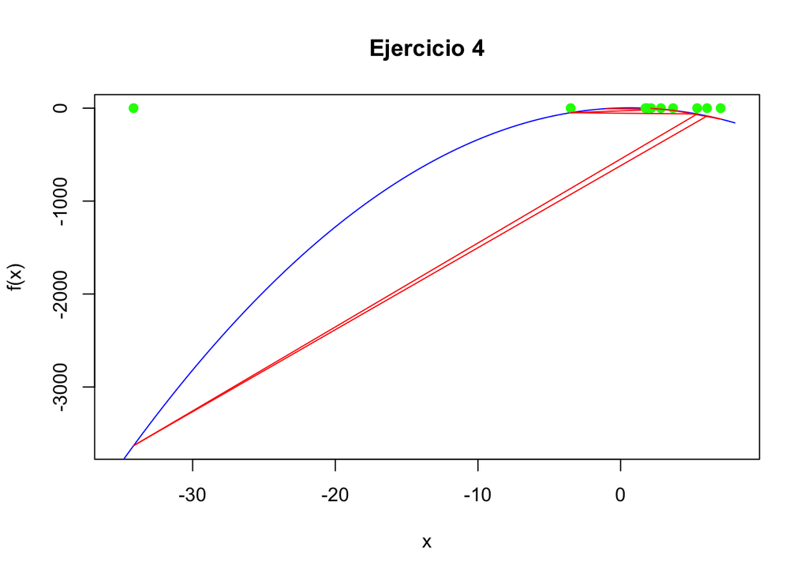

```
##
##
## Ejercicio 5
##    Iter     x_prev     x_curr      f_xcurr     x_next        error
## 1     1 -3.0000000  1.5000000 9.875000e+00 41.0000000 3.950000e+01
## 2     2  1.5000000 41.0000000 7.560300e+04  1.4948400 3.950516e+01
## 3     3 41.0000000  1.4948400 9.783636e+00  1.4897270 5.112947e-03
## 4     4  1.4948400  1.4897270 9.693551e+00  0.9395512 5.501758e-01
## 5     5  1.4897270  0.9395512 2.420869e+00  0.7564132 1.831379e-01
## 6     6  0.9395512  0.7564132 9.650209e-01  0.6350188 1.213945e-01
## 7     7  0.7564132  0.6350188 2.340473e-01  0.5961500 3.886876e-02
## 8     8  0.6350188  0.5961500 3.729804e-02  0.5887816 7.368409e-03
## 9     9  0.5961500  0.5887816 1.982824e-03  0.5883679 4.137101e-04
## 10   10  0.5887816  0.5883679 1.858737e-05  0.5883640 3.914896e-06
```

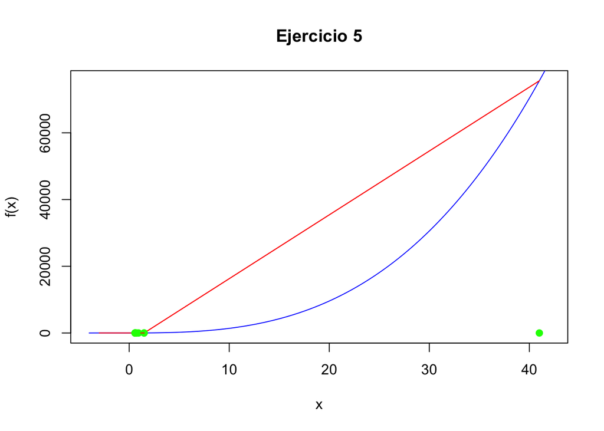

```
##
##
## Ejercicio 6
##   Iter x_prev x_curr f_xcurr x_next error
## 1    1      0      3       4      2     1
## 2    2      3      2       0      2     0
```

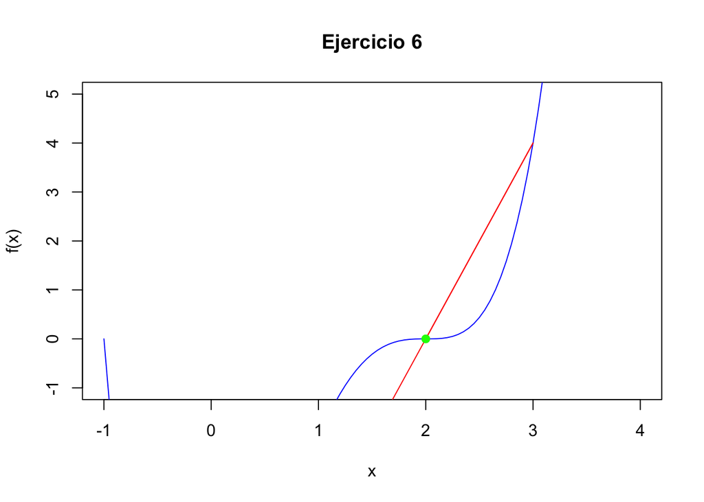

```
##
##
## Ejercicio 7
##   Iter   x_prev   x_curr       f_xcurr   x_next        error
## 1    1 1.000000 2.000000  1.100000e+01 1.266667 7.333333e-01
## 2    2 2.000000 1.266667 -2.425758e+00 1.399165 1.324982e-01
## 3    3 1.266667 1.399165 -1.167558e+00 1.522118 1.229529e-01
## 4    4 1.399165 1.522118  3.677596e-01 1.492666 2.945131e-02
## 5    5 1.522118 1.492666 -3.577871e-02 1.495278 2.611227e-03
## 6    6 1.492666 1.495278 -9.504092e-04 1.495349 7.125623e-05
## 7    7 1.495278 1.495349  2.561314e-06 1.495349 1.915165e-07
```

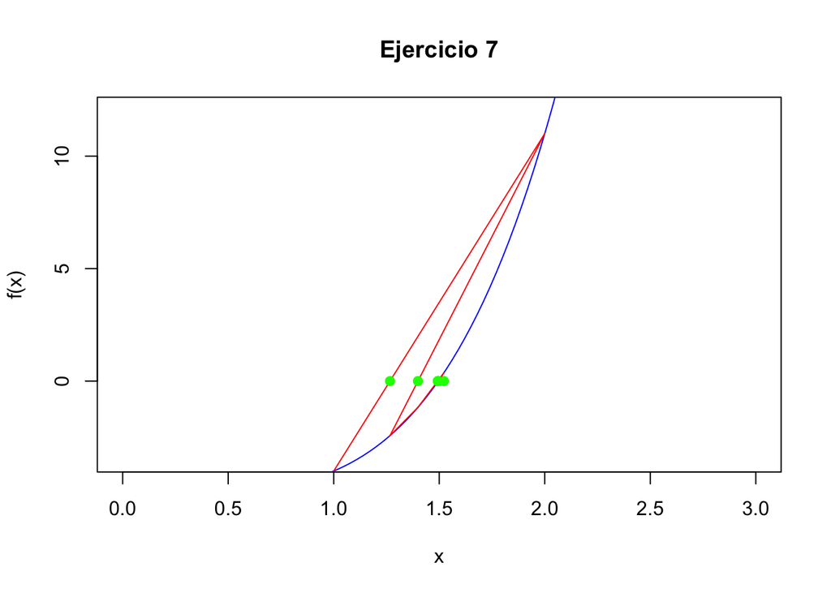

```
##
##
## Ejercicio 8
##    Iter   x_prev   x_curr       f_xcurr   x_next        error
## 1     1 2.000000 4.000000 -2.270000e+02 2.092437 1.907563e+00
## 2     2 4.000000 2.092437  1.033088e+01 2.175472 8.303511e-02
## 3     3 2.092437 2.175472  9.342326e+00 2.960198 7.847264e-01
## 4     4 2.175472 2.960198 -2.821536e+01 2.370670 5.895288e-01
## 5     5 2.960198 2.370670  5.286717e+00 2.463699 9.302922e-02
## 6     6 2.370670 2.463699  2.347519e+00 2.538001 7.430184e-02
## 7     7 2.463699 2.538001 -5.391705e-01 2.524123 1.387796e-02
## 8     8 2.538001 2.524123  3.852597e-02 2.525048 9.255066e-04
## 9     9 2.524123 2.525048  5.633225e-04 2.525062 1.373347e-05
## 10   10 2.525048 2.525062 -6.032783e-07 2.525062 1.469183e-08
```

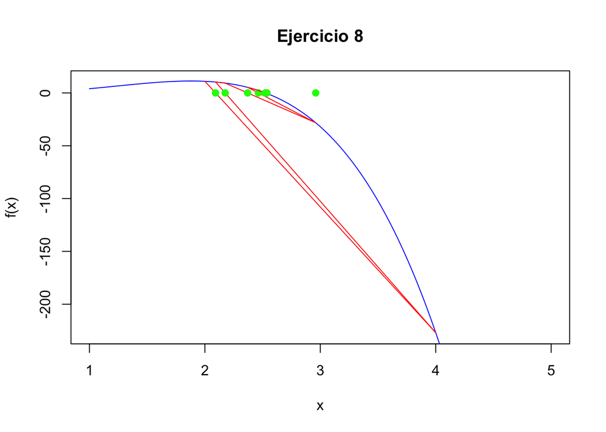

```
##
##
## Ejercicio 9
##   Iter     x_prev     x_curr       f_xcurr     x_next        error
## 1    1  0.0000000  1.5000000 -6.295223e+00 -1.8782042 3.378204e+00
## 2    2  1.5000000 -1.8782042  1.047277e+01  0.2317176 2.109922e+00
## 3    3 -1.8782042  0.2317176 -4.176826e+00 -0.3698538 6.015714e-01
## 4    4  0.2317176 -0.3698538 -2.122748e+00 -0.9915365 6.216827e-01
## 5    5 -0.3698538 -0.9915365  1.342092e+00 -0.7507301 2.408063e-01
## 6    6 -0.9915365 -0.7507301 -2.072663e-01 -0.7829441 3.221399e-02
## 7    7 -0.7507301 -0.7829441 -1.688111e-02 -0.7858005 2.856357e-03
## 8    8 -0.7829441 -0.7858005  2.380094e-04 -0.7857608 3.971231e-05
## 9    9 -0.7858005 -0.7857608 -2.682544e-07 -0.7857608 4.470837e-08
```

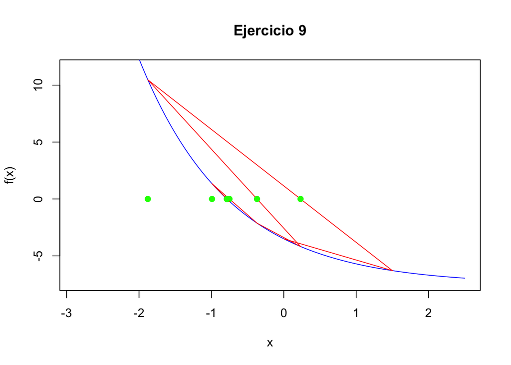

```
##
##
## Ejercicio 10
##   Iter    x_prev    x_curr       f_xcurr    x_next        error
## 1    1 0.0000000 1.1000000  1.598594e+00 0.3001918 7.998082e-01
## 2    2 1.1000000 0.3001918  3.074528e-01 0.1097377 1.904542e-01
## 3    3 0.3001918 0.1097377 -2.298507e-01 0.1912112 8.147356e-02
## 4    4 0.1097377 0.1912112  1.509613e-02 0.1861900 5.021234e-03
## 5    5 0.1912112 0.1861900  6.825577e-04 0.1859522 2.377815e-04
## 6    6 0.1861900 0.1859522 -2.156117e-06 0.1859530 7.487578e-07
```

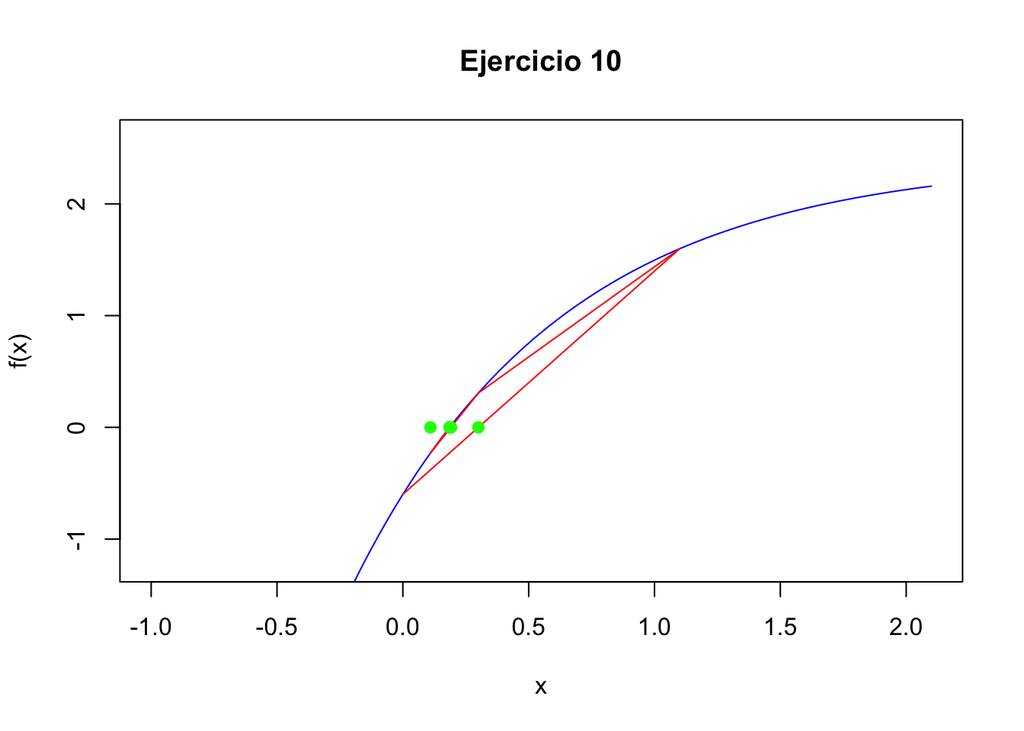

```
##
##
## Ejercicio 11
##   Iter x_prev x_curr   f_xcurr x_next error
## 1    1      0      1 0.5081377      0     1
## 2    2      1      0 0.0000000      0     0
```

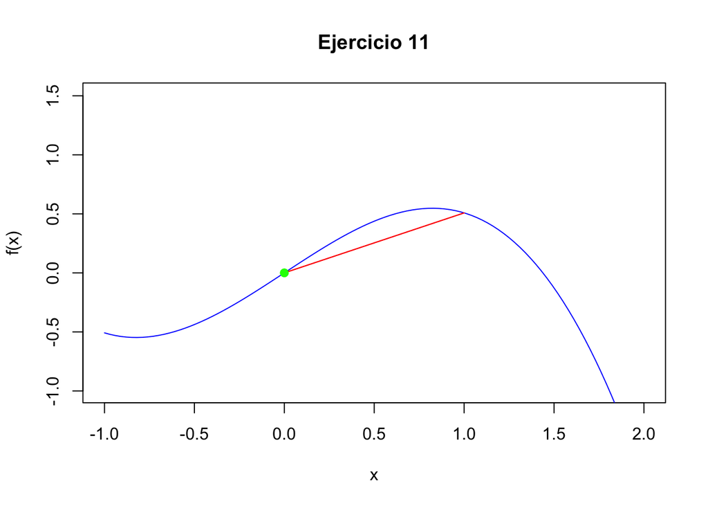

```
##
##
## Ejercicio 12
##   Iter    x_prev    x_curr       f_xcurr    x_next        error
## 1    1 0.3000000 0.8000000 -2.887909e+00 0.4872981 3.127019e-01
## 2    2 0.8000000 0.4872981  3.309091e-01 0.5194452 3.214717e-02
## 3    3 0.4872981 0.5194452  3.869662e-02 0.5237024 4.257132e-03
## 4    4 0.5194452 0.5237024 -9.678839e-04 0.5235985 1.038815e-04
## 5    5 0.5237024 0.5235985  2.599530e-06 0.5235988 2.782563e-07
```

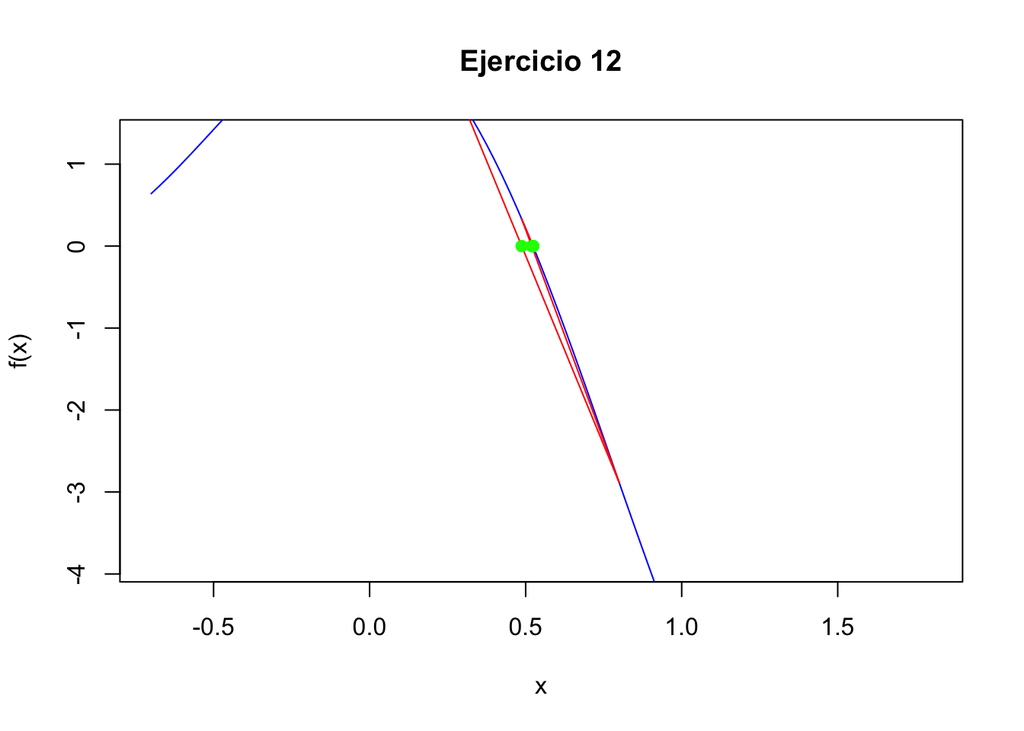

```
##
##
## Ejercicio 13
##   Iter    x_prev    x_curr       f_xcurr    x_next        error
## 1    1 0.0500000 0.3500000  2.585434e-01 0.2703619 7.963806e-02
## 2    2 0.3500000 0.2703619  1.677399e-01 0.1232479 1.471141e-01
## 3    3 0.2703619 0.1232479 -3.565442e-01 0.2232941 1.000463e-01
## 4    4 0.1232479 0.2232941  4.522770e-02 0.2120319 1.126227e-02
## 5    5 0.2232941 0.2120319  8.761119e-03 0.2093261 2.705767e-03
## 6    6 0.2120319 0.2093261 -3.863336e-04 0.2094404 1.142754e-04
## 7    7 0.2093261 0.2094404  2.971779e-06 0.2094395 8.723258e-07
```

[1 more figures not shown]

```r
secante <- function(f, x0, x1, tol = 1e-5, max_iter = 10) {
  iter <- numeric()
  x_prev <- numeric()
  x_curr <- numeric()
  f_curr <- numeric()
  x_next <- numeric()
  error <- numeric()

  for (k in 1:max_iter) {
    f0 <- f(x0)
    f1 <- f(x1)
    x2 <- x1 - f1*(x1 - x0)/(f1 - f0)
    e <- abs(x2 - x1)

    iter <- c(iter, k)
    x_prev <- c(x_prev, x0)
    x_curr <- c(x_curr, x1)
    f_curr <- c(f_curr, f1)
    x_next <- c(x_next, x2)
    error <- c(error, e)

    x0 <- x1
    x1 <- x2

    if (e < tol) break
  }

  resultados <- data.frame(
    Iter = iter,
    x_prev = x_prev,
    x_curr = x_curr,
    f_xcurr = f_curr,
    x_next = x_next,
    error = error
  )

  return(resultados)
}

# Función para graficar las secantes
graficar_secante <- function(f, tabla, titulo = "Método de la Secante") {
  plot(NULL, xlim = c(min(tabla$x_prev, tabla$x_curr) - 1, max(tabla$x_prev, tabla$x_curr) + 1),
       ylim = c(min(tabla$f_xcurr) - 1, max(tabla$f_xcurr) + 1),
       xlab = "x", ylab = "f(x)", main = titulo)
  curve(f(x), from = min(tabla$x_prev, tabla$x_curr) - 1, to = max(tabla$x_prev, tabla$x_curr) + 1, add = TRUE, col = "blue")

  for (i in 1:nrow(tabla)) {
    segments(tabla$x_prev[i], f(tabla$x_prev[i]), tabla$x_curr[i], f(tabla$x_curr[i]), col = "red")
    points(tabla$x_next[i], 0, col = "green", pch = 19)
  }
}

# Lista de funciones y valores iniciales para los 13 ejercicios
funciones <- list(
  function(x) x^2 - 2*x - 3,
  function(x) x^4 - 10*x^2 + 9,
  function(x) 2*x^2 - 5*x + 3,
  function(x) -3*x^2 + 4*x + 2,
  function(x) x^3 + 4*x^2 - x - 1,
  function(x) x^4 - 5*x^3 + 6*x^2 + 4*x - 8,
  function(x) x^4 - 5,
  function(x) -2*x^4 + 3*x^3 + 7*x^2 - 5*x + 1,
  function(x) 4*exp(-0.8*x) - 0.5 - 7,
  function(x) -3*exp(-1.2*x) + 0.4 + 2,
  function(x) sin(x) - x^3/3,
  function(x) (3*x + 3.1)*cos(2*x + pi/6),
  function(x) (-2*x + 1.1)*sin(5*x - pi/3)
)

valores_iniciales <- list(
  c(0,3), c(0,2), c(-1,2), c(-1,3), c(-3,1.5),
  c(0,3), c(1,2), c(2,4), c(0,1.5), c(0,1.1),
  c(0,1), c(0.3,0.8), c(0.05,0.35)
)

# Ejecutar el método y graficar para los 13 ejercicios
resultados_list <- list()

for (i in 1:13) {
  cat("\n\nEjercicio", i, "\n")
  res <- secante(funciones[[i]], valores_iniciales[[i]][1], valores_iniciales[[i]][2])
  print(res)
  resultados_list[[i]] <- res
  graficar_secante(funciones[[i]], res, paste("Ejercicio", i))
}
```